# MIDLIFE TBSS

Daniela Cossio

09/14/2023

# Overview

This is the analysis of white matter using FSLs TBSS

# Methods

**Participants**

**Scan parameters**

- Locations from UCSB and UCI

**QSIprep**

- Version used: 0.16.0RC3
- The following parameters were used
  - dwi_denoise_window **5**
  - hmc_model **3dSHORE**
  - hmc-transform **Rigid**
  - shoreline_iters **2**

**Preprocessing for FSL**

The data needs to be reconstructed and prepared for FSL.

- Run FSL dti fit in order to extract our statistics. It fits a tensor model at each voxel.
  - You need the following inputs
    - DWI scan images
    - BRain mask image
    - Output name
    - Bvec files
    - B value files
- We need to reorient the images to be in the same format as FSL atlases.
  - We run FSL reorient on each image

**FSL TBSS**

- **Step 1:** tbss _1_preproc *nii.gz
  - this prepares the data for full preprocessing
- **Step 2:** tbss_2_reg
  - This runs a nonlinear registration and creates transforms of all the images in order to put them into a standard space
- **Step 3:** tbss_3_postreg
  - Applies all of the transofrms created in the previous step
- **Intermediate Step:** Quality check
  - Open all images in FSL and visually inspect that they line up with the mean FA
- **Step 4:** tbss_4_prestats
  - Creates a threshold for each of the masks in order to extract stats
- **Custom scripts**
  - here we use custoim fsl maths and meants scripts in order to extract our values for the JHU atlas

## Overall approach for analysis

First, I will run analysis using our aprior rois - Fornix - Cingulum bundle (L and R)

Here, I will run a partial correlation and control for sex and age. Then I will run a multiple linear regression using sex and age as covariates. Then If there is a sex effect, I will run a sex stratisfied analysis using a partial correlation and controlling for age.

# Results

## Behavior Distributions

### Maze Accuracy

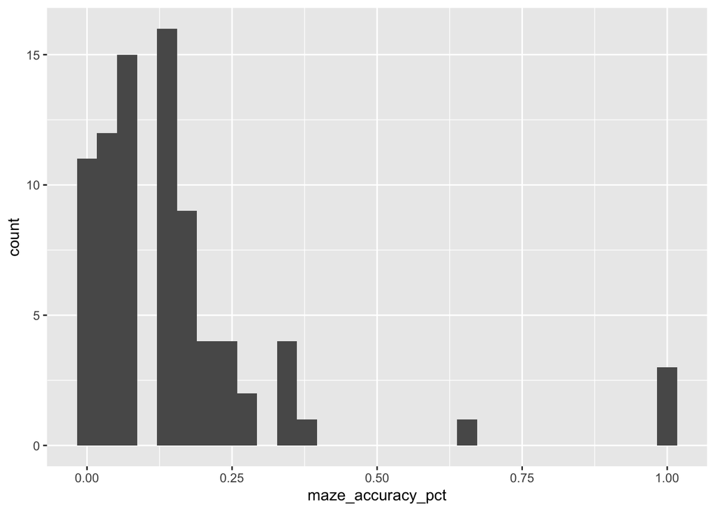

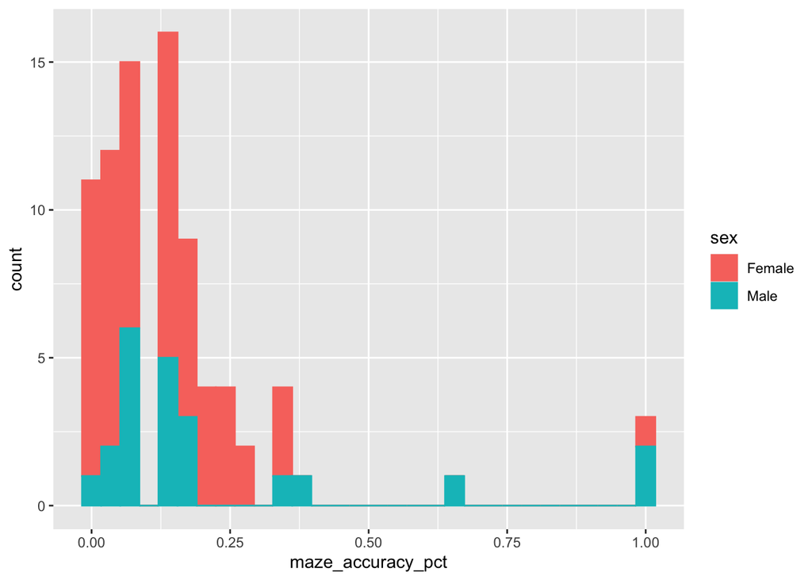

Let’s just double check that by running a normality test.

The data is not normally distributed with p = 6.1641918^{-13}.

### DSP

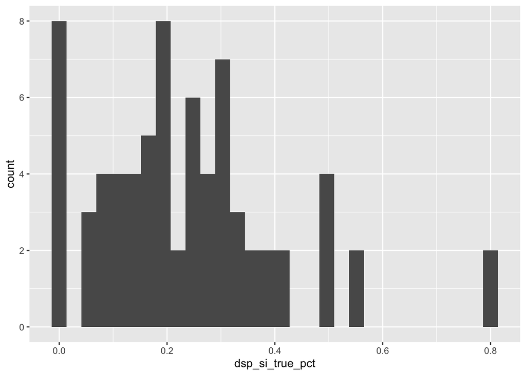

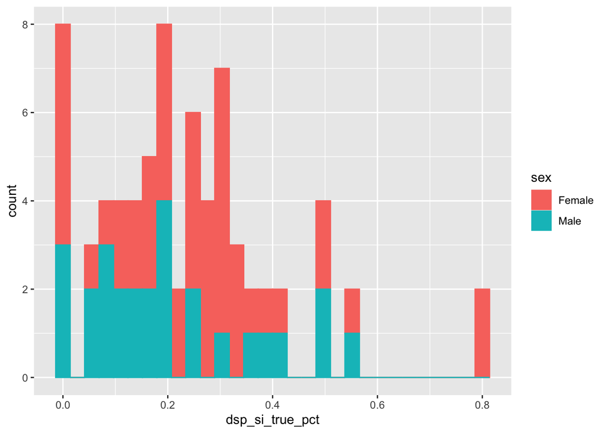

### Loop

#### AE

Average

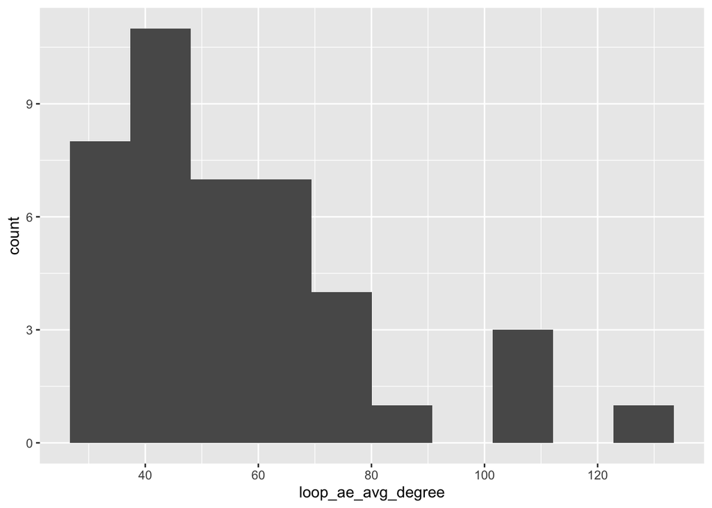

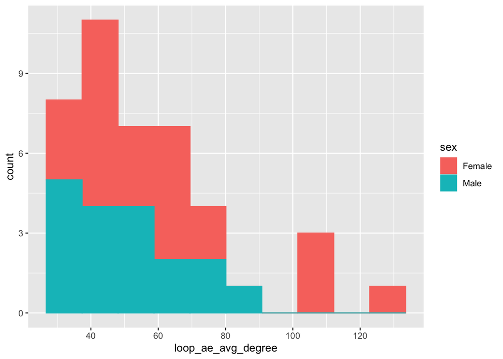

Rad3

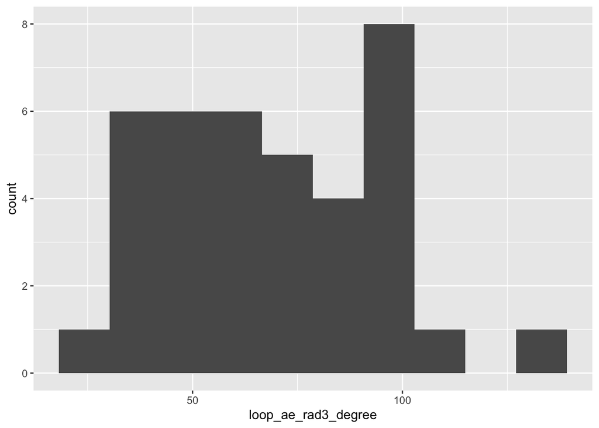

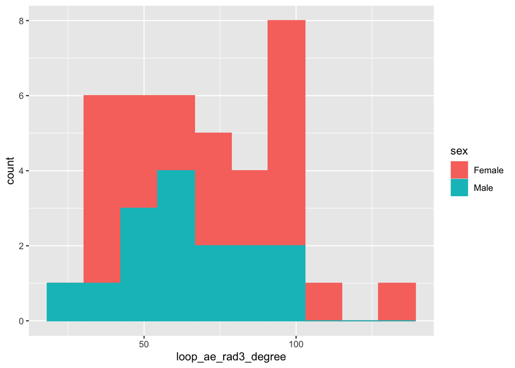

#### DE

Average

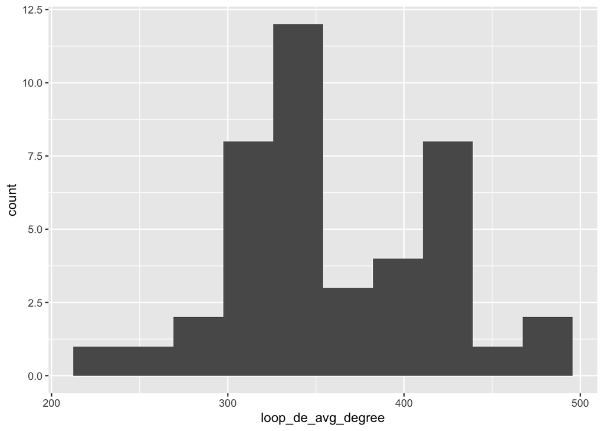

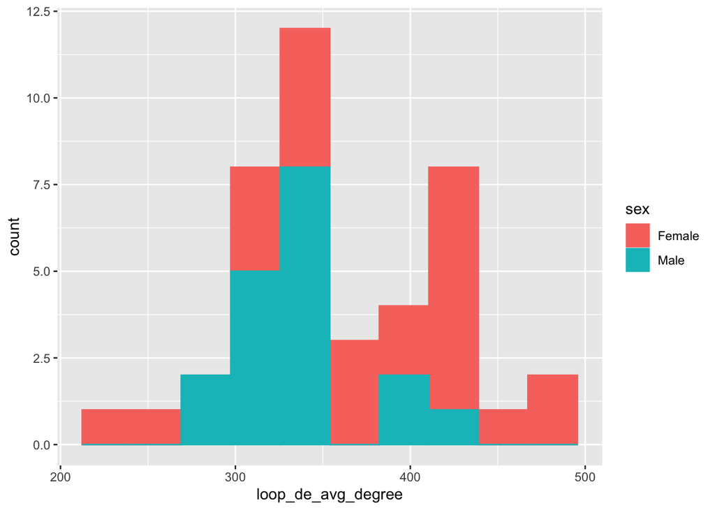

Rad3

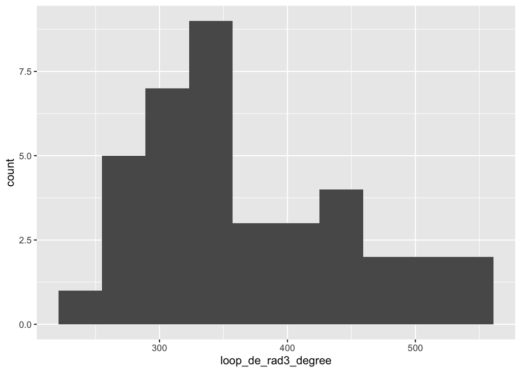

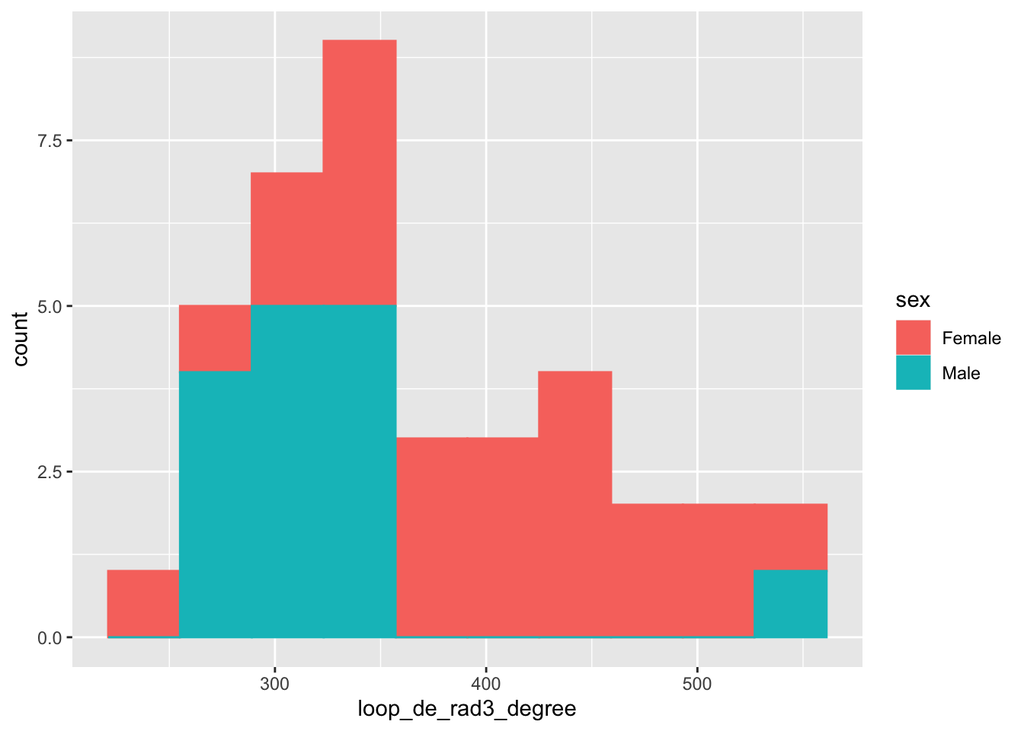

#### PE

Average

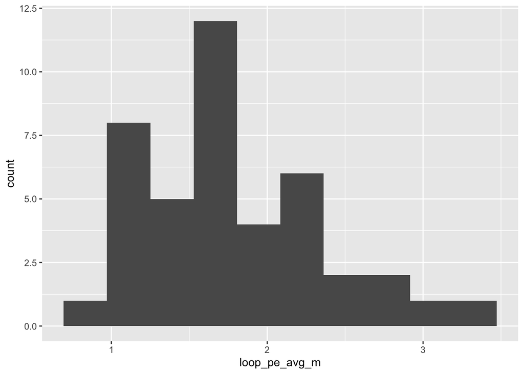

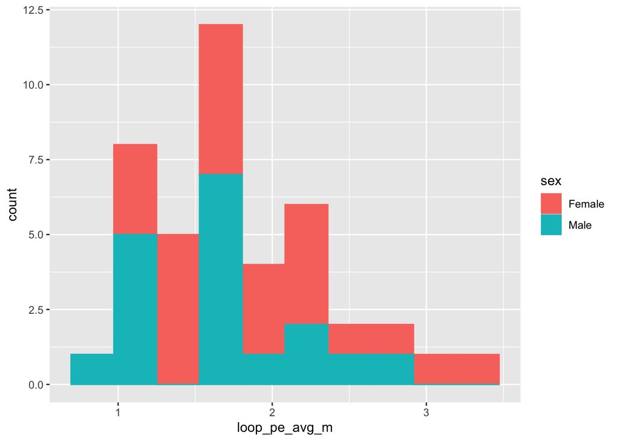

Rad3

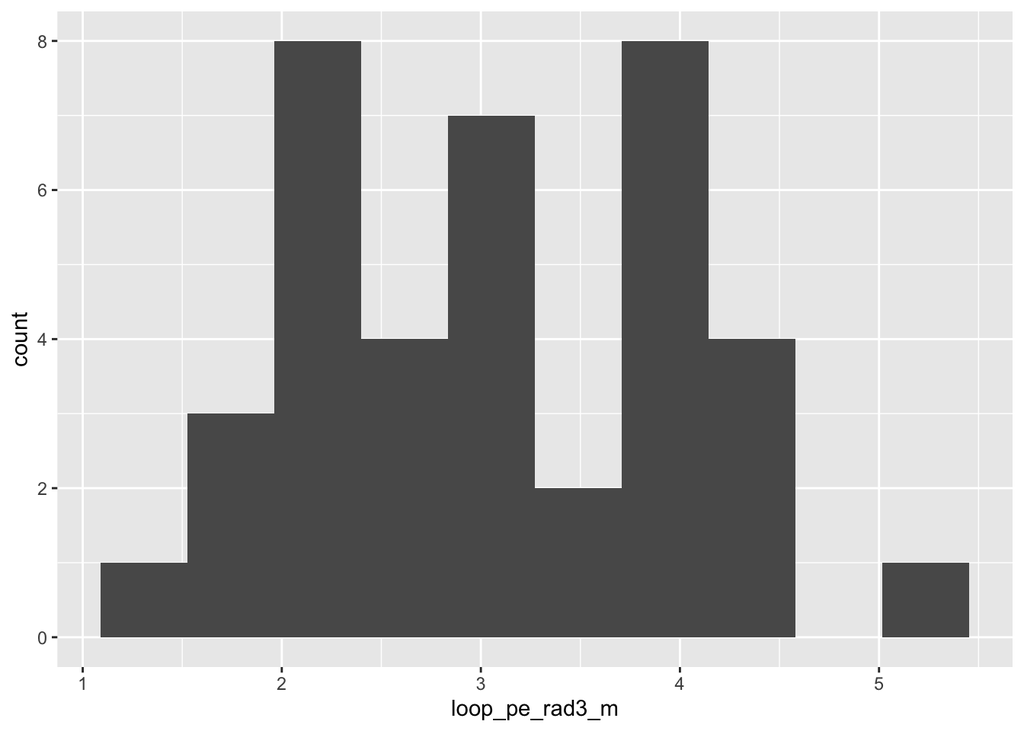

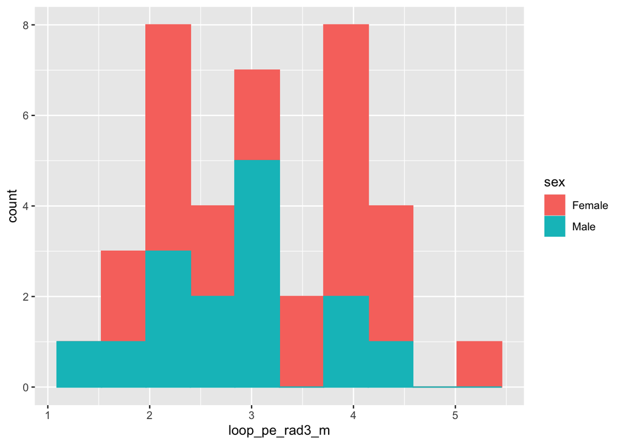

## FA

### Apriori

First, let’s start with our apriori regions: Fornix body fornix (L and R), Cingulum bundle (cingulate gyrus and hippocampus ) L and R.

#### **Maze Accuracy**

##### Partial Correlations

Here we want to know whether ROIs correlate to our different behavioral variables when we control for age and sex. So we will run partial correlations.When controlling for age and sex, our ROIS are not significantly correlated

| ROI | estimate | p.value | statistic | n | gp | Method |
| --- | --- | --- | --- | --- | --- | --- |
| fornix_body | 0.0283708 | 0.8027319 | 0.2506654 | 82 | 2 | spearman |
| fornix_R | -0.1231199 | 0.2765809 | -1.0957018 | 82 | 2 | spearman |
| fornix_L | -0.0624025 | 0.5823903 | -0.5521999 | 82 | 2 | spearman |
| Cingulum_(cingulate_gyrus)_R | -0.0441740 | 0.6972200 | -0.3905153 | 82 | 2 | spearman |
| Cingulum_(cingulate_gyrus)_L | -0.0129041 | 0.9095500 | -0.1139756 | 82 | 2 | spearman |
| Cingulum_(hippocampus)_R | -0.1562873 | 0.1662362 | -1.3974649 | 82 | 2 | spearman |
| Cingulum_(hippocampus)_L | -0.0691954 | 0.5419322 | -0.6125858 | 82 | 2 | spearman |

##### Multiple Linear Regression

**Fornix**

Fornix Body

| term | estimate | std.error | statistic | p.value |
| --- | --- | --- | --- | --- |
| (Intercept) | 0.7053781 | 0.3167090 | 2.2272122 | 0.0288163 |
| fornix_body | 0.6447883 | 1.4092429 | 0.4575423 | 0.6485532 |
| sex | 0.0964754 | 0.0476308 | 2.0254818 | 0.0462384 |
| age | -0.0124711 | 0.0058432 | -2.1343145 | 0.0359581 |

Fornix R

| term | estimate | std.error | statistic | p.value |
| --- | --- | --- | --- | --- |
| (Intercept) | 0.9417698 | 0.4150881 | 2.2688431 | 0.0260420 |
| fornix_R | -1.2824182 | 2.0484497 | -0.6260433 | 0.5331143 |
| sex | 0.0884553 | 0.0490124 | 1.8047527 | 0.0749729 |
| age | -0.0125318 | 0.0058375 | -2.1467682 | 0.0349191 |

Fornix L

| term | estimate | std.error | statistic | p.value |
| --- | --- | --- | --- | --- |
| (Intercept) | 1.0302569 | 0.4376049 | 2.3543084 | 0.0210739 |
| fornix_L | -1.7491420 | 2.0879894 | -0.8377159 | 0.4047499 |
| sex | 0.0815650 | 0.0504446 | 1.6169220 | 0.1099326 |
| age | -0.0125596 | 0.0058261 | -2.1557643 | 0.0341849 |

**Cingulum Bundle**

Cingulum_(cingulate_gyrus)_R

| term | estimate | std.error | statistic | p.value |
| --- | --- | --- | --- | --- |
| (Intercept) | 1.0252866 | 0.4071834 | 2.5179969 | 0.0138506 |
| Cingulum_(cingulate_gyrus)_R | -4.0237187 | 4.2590206 | -0.9447521 | 0.3477028 |
| sex | 0.0917566 | 0.0476064 | 1.9274029 | 0.0575703 |
| age | -0.0115499 | 0.0058961 | -1.9589006 | 0.0536984 |

Cingulum_(cingulate_gyrus)_L

| term | estimate | std.error | statistic | p.value |
| --- | --- | --- | --- | --- |
| (Intercept) | 0.9927537 | 0.4028332 | 2.4644289 | 0.0159224 |
| Cingulum_(cingulate_gyrus)_L | -3.1088902 | 3.6594902 | -0.8495419 | 0.3981799 |
| sex | 0.0934995 | 0.0475400 | 1.9667534 | 0.0527684 |
| age | -0.0116595 | 0.0058989 | -1.9765604 | 0.0516262 |

Cingulum_(hippocampus)_R

| term | estimate | std.error | statistic | p.value |
| --- | --- | --- | --- | --- |
| (Intercept) | 0.8803922 | 0.3487588 | 2.5243585 | 0.0136214 |
| Cingulum_(hippocampus)_R | -1.4766971 | 2.2684888 | -0.6509607 | 0.5169850 |
| sex | 0.0870572 | 0.0494402 | 1.7608576 | 0.0821819 |
| age | -0.0121485 | 0.0058541 | -2.0752241 | 0.0412624 |

Cingulum_(hippocampus)_L

| term | estimate | std.error | statistic | p.value |
| --- | --- | --- | --- | --- |
| (Intercept) | 0.9448289 | 0.3641720 | 2.5944579 | 0.0113129 |
| Cingulum_(hippocampus)_L | -2.0498718 | 2.3699297 | -0.8649505 | 0.3897184 |
| sex | 0.0866497 | 0.0486340 | 1.7816718 | 0.0786951 |
| age | -0.0124720 | 0.0058231 | -2.1418239 | 0.0353284 |

##### Sex stratified partial correlations

**Males**

| ROI | estimate | p.value | statistic | n | gp | Method |
| --- | --- | --- | --- | --- | --- | --- |
| fornix_body | -0.0425957 | 0.8545407 | -0.1858390 | 22 | 1 | spearman |
| fornix_R | -0.1992971 | 0.3864317 | -0.8864998 | 22 | 1 | spearman |
| fornix_L | 0.2594935 | 0.2559872 | 1.1712265 | 22 | 1 | spearman |
| Cingulum_(cingulate_gyrus)_R | -0.0259521 | 0.9110903 | -0.1131606 | 22 | 1 | spearman |
| Cingulum_(cingulate_gyrus)_L | -0.0110683 | 0.9620216 | -0.0482488 | 22 | 1 | spearman |
| Cingulum_(hippocampus)_R | -0.1266145 | 0.5844467 | -0.5563777 | 22 | 1 | spearman |
| Cingulum_(hippocampus)_L | 0.0438551 | 0.8502860 | 0.1913441 | 22 | 1 | spearman |

**Females**

For women, nothing was significantly correlated

| ROI | estimate | p.value | statistic | n | gp | Method |
| --- | --- | --- | --- | --- | --- | --- |
| fornix_body | 0.0459754 | 0.7295152 | 0.3474738 | 60 | 1 | spearman |
| fornix_R | -0.0783801 | 0.5551397 | -0.5935825 | 60 | 1 | spearman |
| fornix_L | -0.0812196 | 0.5408532 | -0.6152274 | 60 | 1 | spearman |
| Cingulum_(cingulate_gyrus)_R | -0.0283538 | 0.8311921 | -0.2141529 | 60 | 1 | spearman |
| Cingulum_(cingulate_gyrus)_L | 0.0041829 | 0.9749167 | 0.0315808 | 60 | 1 | spearman |
| Cingulum_(hippocampus)_R | -0.1742580 | 0.1868391 | -1.3360610 | 60 | 1 | spearman |
| Cingulum_(hippocampus)_L | -0.0997679 | 0.4521631 | -0.7570078 | 60 | 1 | spearman |

#### **Dual Solution Paradigm**

##### Partial Correlations

| ROI | estimate | p.value | statistic | n | gp | Method |
| --- | --- | --- | --- | --- | --- | --- |
| fornix_body | 0.2561756 | 0.0323074 | 2.1854048 | 72 | 2 | spearman |
| fornix_R | 0.1726414 | 0.1529554 | 1.4453398 | 72 | 2 | spearman |
| fornix_L | 0.1430579 | 0.2374259 | 1.1919455 | 72 | 2 | spearman |
| Cingulum_(cingulate_gyrus)_R | 0.0238618 | 0.8445513 | 0.1968254 | 72 | 2 | spearman |
| Cingulum_(cingulate_gyrus)_L | -0.0592301 | 0.6262160 | -0.4892829 | 72 | 2 | spearman |
| Cingulum_(hippocampus)_R | 0.1847556 | 0.1257302 | 1.5502219 | 72 | 2 | spearman |
| Cingulum_(hippocampus)_L | 0.0790679 | 0.5152799 | 0.6540587 | 72 | 2 | spearman |

##### Multiple Linear Regression

Mostly effects of age with some effects of sex. Fornix body appears to have an effect of sex.

**Fornix**

Fornix Body

[output not shown]

Fornix R

[output not shown]

Fornix L

[output not shown]

**Cingulum Bundle**

Cingulum_(cingulate_gyrus)_R

[output not shown]

Cingulum_(cingulate_gyrus)_L

[output not shown]

Cingulum_(hippocampus)_R

[output not shown]

Cingulum_(hippocampus)_L

[output not shown]

##### Sex stratified partial correlations

**Males**

For males, the fornix body and right cingulum hippocampus were significantly correlated

| ROI | estimate | p.value | statistic | n | gp | Method |
| --- | --- | --- | --- | --- | --- | --- |
| fornix_body | 0.4321806 | 0.0274610 | 2.3478314 | 27 | 1 | spearman |
| fornix_R | 0.3352380 | 0.0940988 | 1.7431971 | 27 | 1 | spearman |
| fornix_L | 0.1658653 | 0.4180622 | 0.8239844 | 27 | 1 | spearman |
| Cingulum_(cingulate_gyrus)_R | 0.1169266 | 0.5694607 | 0.5767775 | 27 | 1 | spearman |
| Cingulum_(cingulate_gyrus)_L | -0.0210833 | 0.9185757 | -0.1033095 | 27 | 1 | spearman |
| Cingulum_(hippocampus)_R | 0.4039264 | 0.0407100 | 2.1631454 | 27 | 1 | spearman |
| Cingulum_(hippocampus)_L | 0.1558882 | 0.4469850 | 0.7731450 | 27 | 1 | spearman |

**Females**

For women, nothing was significantly correlated

| ROI | estimate | p.value | statistic | n | gp | Method |
| --- | --- | --- | --- | --- | --- | --- |
| fornix_body | 0.1444235 | 0.3496159 | 0.9458882 | 45 | 1 | spearman |
| fornix_R | 0.1330194 | 0.3893572 | 0.8697934 | 45 | 1 | spearman |
| fornix_L | 0.1817465 | 0.2377106 | 1.1978011 | 45 | 1 | spearman |
| Cingulum_(cingulate_gyrus)_R | -0.0485030 | 0.7545430 | -0.3147061 | 45 | 1 | spearman |
| Cingulum_(cingulate_gyrus)_L | -0.0568822 | 0.7138064 | -0.3692367 | 45 | 1 | spearman |
| Cingulum_(hippocampus)_R | 0.0525584 | 0.7347372 | 0.3410889 | 45 | 1 | spearman |
| Cingulum_(hippocampus)_L | 0.0485927 | 0.7541034 | 0.3152891 | 45 | 1 | spearman |

#### **Loop Degrees Traveled**

##### Radius 3

###### Partial Correlations

| ROI | estimate | p.value | statistic | n | gp | Method |
| --- | --- | --- | --- | --- | --- | --- |
| fornix_body | -0.2010221 | 0.2397493 | -1.1965762 | 38 | 2 | spearman |
| fornix_R | -0.1280364 | 0.4567690 | -0.7527697 | 38 | 2 | spearman |
| fornix_L | -0.2346861 | 0.1682797 | -1.4077605 | 38 | 2 | spearman |
| Cingulum_(cingulate_gyrus)_R | 0.1824280 | 0.2869182 | 1.0818835 | 38 | 2 | spearman |
| Cingulum_(cingulate_gyrus)_L | 0.3325684 | 0.0475011 | 2.0562327 | 38 | 2 | spearman |
| Cingulum_(hippocampus)_R | -0.0556377 | 0.7472295 | -0.3249240 | 38 | 2 | spearman |
| Cingulum_(hippocampus)_L | -0.1768645 | 0.3021193 | -1.0478070 | 38 | 2 | spearman |

###### Multiple Linear Regression

Sex appears to have the largest effect on all ROIs

**ROIS**

**Fornix**

Fornix Body

| term | estimate | std.error | statistic | p.value |
| --- | --- | --- | --- | --- |
| (Intercept) | 359.9480468 | 205.695606 | 1.7499063 | 0.0891560 |
| fornix_body | -131.2736100 | 759.305745 | -0.1728864 | 0.8637659 |
| sex | -67.3134665 | 26.373788 | -2.5522866 | 0.0153645 |
| age | 0.9050628 | 3.670421 | 0.2465828 | 0.8067139 |

Fornix R

| term | estimate | std.error | statistic | p.value |
| --- | --- | --- | --- | --- |
| (Intercept) | 473.149042 | 231.580912 | 2.0431263 | 0.0488525 |
| fornix_R | -955.050332 | 1062.679208 | -0.8987193 | 0.3751231 |
| sex | -70.099865 | 26.126306 | -2.6831142 | 0.0111822 |
| age | 1.028516 | 3.581666 | 0.2871612 | 0.7757318 |

Fornix L

| term | estimate | std.error | statistic | p.value |
| --- | --- | --- | --- | --- |
| (Intercept) | 686.2943199 | 284.327710 | 2.4137441 | 0.0213241 |
| fornix_L | -1848.6557418 | 1199.018214 | -1.5418079 | 0.1323773 |
| sex | -72.3538143 | 25.552792 | -2.8315424 | 0.0077275 |
| age | -0.3076032 | 3.605811 | -0.0853076 | 0.9325172 |

**Cingulum**

Cingulum_(cingulate_gyrus)_R

| term | estimate | std.error | statistic | p.value |
| --- | --- | --- | --- | --- |
| (Intercept) | 92.7733397 | 308.720194 | 0.3005095 | 0.7656185 |
| Cingulum_(cingulate_gyrus)_R | 3316.0291016 | 3302.303626 | 1.0041563 | 0.3223966 |
| sex | -65.5678201 | 25.805058 | -2.5408903 | 0.0157898 |
| age | 0.8755629 | 3.573728 | 0.2449999 | 0.8079292 |

Cingulum_(cingulate_gyrus)_L

| term | estimate | std.error | statistic | p.value |
| --- | --- | --- | --- | --- |
| (Intercept) | -99.7633351 | 271.031455 | -0.3680877 | 0.7150897 |
| Cingulum_(cingulate_gyrus)_L | 5136.5677020 | 2419.488146 | 2.1229977 | 0.0411148 |
| sex | -72.9307420 | 24.754183 | -2.9461987 | 0.0057726 |
| age | 0.8112225 | 3.406458 | 0.2381425 | 0.8132000 |

Cingulum_(hippocampus)_R

| term | estimate | std.error | statistic | p.value |
| --- | --- | --- | --- | --- |
| (Intercept) | 420.049162 | 224.903732 | 1.8676843 | 0.0704458 |
| Cingulum_(hippocampus)_R | -855.173359 | 1472.164132 | -0.5808954 | 0.5651420 |
| sex | -69.288809 | 26.403911 | -2.6241873 | 0.0129151 |
| age | 1.036348 | 3.606374 | 0.2873655 | 0.7755767 |

Cingulum_(hippocampus)_L

| term | estimate | std.error | statistic | p.value |
| --- | --- | --- | --- | --- |
| (Intercept) | 466.6054952 | 230.748296 | 2.0221406 | 0.0510865 |
| Cingulum_(hippocampus)_L | -1294.2546930 | 1500.489707 | -0.8625549 | 0.3944257 |
| sex | -69.8923781 | 26.137965 | -2.6739793 | 0.0114359 |
| age | 0.8550832 | 3.589223 | 0.2382363 | 0.8131278 |

###### Sex stratified partial correlations

**Males**

| ROI | estimate | p.value | statistic | n | gp | Method |
| --- | --- | --- | --- | --- | --- | --- |
| fornix_body | -0.2159524 | 0.4583881 | -0.7661595 | 15 | 1 | spearman |
| fornix_R | -0.1111277 | 0.7052746 | -0.3873568 | 15 | 1 | spearman |
| fornix_L | -0.2669289 | 0.3562499 | -0.9594823 | 15 | 1 | spearman |
| Cingulum_(cingulate_gyrus)_R | -0.1745515 | 0.5506199 | -0.6140915 | 15 | 1 | spearman |
| Cingulum_(cingulate_gyrus)_L | -0.1125461 | 0.7016692 | -0.3923639 | 15 | 1 | spearman |
| Cingulum_(hippocampus)_R | -0.3612279 | 0.2044554 | -1.3419413 | 15 | 1 | spearman |
| Cingulum_(hippocampus)_L | -0.3903544 | 0.1676213 | -1.4687512 | 15 | 1 | spearman |

**Females**

| ROI | estimate | p.value | statistic | n | gp | Method |
| --- | --- | --- | --- | --- | --- | --- |
| fornix_body | -0.2098201 | 0.3486621 | -0.9597071 | 23 | 1 | spearman |
| fornix_R | -0.1113124 | 0.6218977 | -0.5009171 | 23 | 1 | spearman |
| fornix_L | -0.2144383 | 0.3379090 | -0.9818372 | 23 | 1 | spearman |
| Cingulum_(cingulate_gyrus)_R | 0.4894181 | 0.0207897 | 2.5098861 | 23 | 1 | spearman |
| Cingulum_(cingulate_gyrus)_L | 0.6044122 | 0.0028884 | 3.3928822 | 23 | 1 | spearman |
| Cingulum_(hippocampus)_R | 0.1125367 | 0.6180461 | 0.5064969 | 23 | 1 | spearman |
| Cingulum_(hippocampus)_L | -0.0044648 | 0.9842671 | -0.0199675 | 23 | 1 | spearman |

##### Average

###### Partial Correlations

| ROI | estimate | p.value | statistic | n | gp | Method |
| --- | --- | --- | --- | --- | --- | --- |
| fornix_body | -0.2229740 | 0.1666721 | -1.4100017 | 42 | 2 | spearman |
| fornix_R | -0.0397860 | 0.8074276 | -0.2454515 | 42 | 2 | spearman |
| fornix_L | -0.1202576 | 0.4598180 | -0.7467367 | 42 | 2 | spearman |
| Cingulum_(cingulate_gyrus)_R | 0.2271424 | 0.1586808 | 1.4377814 | 42 | 2 | spearman |
| Cingulum_(cingulate_gyrus)_L | 0.3221752 | 0.0426197 | 2.0978803 | 42 | 2 | spearman |
| Cingulum_(hippocampus)_R | 0.0358541 | 0.8261507 | 0.2211617 | 42 | 2 | spearman |
| Cingulum_(hippocampus)_L | -0.0217320 | 0.8941121 | -0.1339970 | 42 | 2 | spearman |

###### Multiple Linear Regression

**Fornix**

Fornix Body

| term | estimate | std.error | statistic | p.value |
| --- | --- | --- | --- | --- |
| (Intercept) | 380.1621596 | 137.148206 | 2.7719076 | 0.0085827 |
| fornix_body | -472.4402553 | 524.659048 | -0.9004710 | 0.3735412 |
| sex | -41.9693618 | 17.913993 | -2.3428256 | 0.0244753 |
| age | 0.7128714 | 2.459394 | 0.2898566 | 0.7735018 |

Fornix R

| term | estimate | std.error | statistic | p.value |
| --- | --- | --- | --- | --- |
| (Intercept) | 365.621947 | 164.195379 | 2.226749 | 0.0319669 |
| fornix_R | -292.336878 | 772.048274 | -0.378651 | 0.7070544 |
| sex | -41.344243 | 18.255404 | -2.264767 | 0.0293137 |
| age | 1.026534 | 2.453242 | 0.418440 | 0.6779810 |

Fornix L

| term | estimate | std.error | statistic | p.value |
| --- | --- | --- | --- | --- |
| (Intercept) | 474.7446604 | 205.532219 | 2.3098308 | 0.0264253 |
| fornix_L | -802.8617004 | 883.011284 | -0.9092315 | 0.3689589 |
| sex | -42.7926457 | 18.035798 | -2.3726505 | 0.0228252 |
| age | 0.4517793 | 2.517114 | 0.1794830 | 0.8585121 |

**Cingulum**

Cingulum_(cingulate_gyrus)_R

| term | estimate | std.error | statistic | p.value |
| --- | --- | --- | --- | --- |
| (Intercept) | 43.9546178 | 210.036058 | 0.2092718 | 0.8353540 |
| Cingulum_(cingulate_gyrus)_R | 3826.1577216 | 2351.812391 | 1.6268975 | 0.1120241 |
| sex | -39.6650123 | 17.385446 | -2.2815067 | 0.0282093 |
| age | 0.7209785 | 2.384357 | 0.3023785 | 0.7640125 |

Cingulum_(cingulate_gyrus)_L

| term | estimate | std.error | statistic | p.value |
| --- | --- | --- | --- | --- |
| (Intercept) | -20.305385 | 188.903209 | -0.1074909 | 0.9149650 |
| Cingulum_(cingulate_gyrus)_L | 4068.007595 | 1758.506340 | 2.3133312 | 0.0262120 |
| sex | -45.038151 | 16.968782 | -2.6541770 | 0.0115457 |
| age | 0.768363 | 2.303815 | 0.3335176 | 0.7405770 |

Cingulum_(hippocampus)_R

| term | estimate | std.error | statistic | p.value |
| --- | --- | --- | --- | --- |
| (Intercept) | 320.95769 | 152.785385 | 2.1007094 | 0.0423558 |
| Cingulum_(hippocampus)_R | 42.76843 | 1023.706426 | 0.0417780 | 0.9668944 |
| sex | -39.90308 | 18.443255 | -2.1635598 | 0.0368522 |
| age | 1.04202 | 2.458383 | 0.4238641 | 0.6740548 |

Cingulum_(hippocampus)_L

| term | estimate | std.error | statistic | p.value |
| --- | --- | --- | --- | --- |
| (Intercept) | 324.6702779 | 165.079438 | 1.9667518 | 0.0565460 |
| Cingulum_(hippocampus)_L | 0.2572046 | 1077.213270 | 0.0002388 | 0.9998107 |
| sex | -40.0741298 | 18.331997 | -2.1860210 | 0.0350446 |
| age | 1.0450987 | 2.470795 | 0.4229807 | 0.6746936 |

###### Sex stratified partial correlations

Males

| ROI | estimate | p.value | statistic | n | gp | Method |
| --- | --- | --- | --- | --- | --- | --- |
| fornix_body | -0.1608685 | 0.5373701 | -0.6312628 | 18 | 1 | spearman |
| fornix_R | 0.0033683 | 0.9897633 | 0.0130456 | 18 | 1 | spearman |
| fornix_L | -0.1250540 | 0.6324925 | -0.4881642 | 18 | 1 | spearman |
| Cingulum_(cingulate_gyrus)_R | 0.0519520 | 0.8430290 | 0.2014814 | 18 | 1 | spearman |
| Cingulum_(cingulate_gyrus)_L | -0.0828754 | 0.7518350 | -0.3220829 | 18 | 1 | spearman |
| Cingulum_(hippocampus)_R | -0.1786556 | 0.4926754 | -0.7032442 | 18 | 1 | spearman |
| Cingulum_(hippocampus)_L | -0.2251665 | 0.3848977 | -0.8950508 | 18 | 1 | spearman |

```r
model1 <- lm(loop_de_rad3_degree ~ `Cingulum_(cingulate_gyrus)_L` + age_scan_years, data = female_apriori_FA)
```

Females

| ROI | estimate | p.value | statistic | n | gp | Method |
| --- | --- | --- | --- | --- | --- | --- |
| fornix_body | -0.2885526 | 0.1817819 | -1.3810589 | 24 | 1 | spearman |
| fornix_R | -0.0527394 | 0.8111130 | -0.2420193 | 24 | 1 | spearman |
| fornix_L | -0.1843375 | 0.3997869 | -0.8594693 | 24 | 1 | spearman |
| Cingulum_(cingulate_gyrus)_R | 0.3475695 | 0.1041505 | 1.6986683 | 24 | 1 | spearman |
| Cingulum_(cingulate_gyrus)_L | 0.5094585 | 0.0130249 | 2.7131263 | 24 | 1 | spearman |
| Cingulum_(hippocampus)_R | 0.1284855 | 0.5590441 | 0.5937155 | 24 | 1 | spearman |
| Cingulum_(hippocampus)_L | 0.0769375 | 0.7271491 | 0.3536199 | 24 | 1 | spearman |

#### **Loop Position Error**

##### Radius 3

###### Partial Correlations

| ROI | estimate | p.value | statistic | n | gp | Method |
| --- | --- | --- | --- | --- | --- | --- |
| fornix_body | 0.2825692 | 0.0949578 | 1.7176468 | 38 | 2 | spearman |
| fornix_R | -0.0067578 | 0.9687979 | -0.0394051 | 38 | 2 | spearman |
| fornix_L | 0.1500853 | 0.3822844 | 0.8851663 | 38 | 2 | spearman |
| Cingulum_(cingulate_gyrus)_R | 0.1961538 | 0.2515601 | 1.1664233 | 38 | 2 | spearman |
| Cingulum_(cingulate_gyrus)_L | 0.1267165 | 0.4614611 | 0.7448822 | 38 | 2 | spearman |
| Cingulum_(hippocampus)_R | 0.0256071 | 0.8821497 | 0.1493630 | 38 | 2 | spearman |
| Cingulum_(hippocampus)_L | 0.2041260 | 0.2324171 | 1.2158490 | 38 | 2 | spearman |

###### Multiple Linear Regression

**Fornix**

Fornix Body

| term | estimate | std.error | statistic | p.value |
| --- | --- | --- | --- | --- |
| (Intercept) | 2.2345788 | 2.3501322 | 0.9508311 | 0.3484007 |
| fornix_body | 15.6921635 | 8.6752891 | 1.8088346 | 0.0793273 |
| sex | -0.3330684 | 0.3013282 | -1.1053342 | 0.2767754 |
| age | -0.0059656 | 0.0419356 | -0.1422557 | 0.8877177 |

Fornix R

| term | estimate | std.error | statistic | p.value |
| --- | --- | --- | --- | --- |
| (Intercept) | 3.5947437 | 2.7975149 | 1.2849775 | 0.2074853 |
| fornix_R | 4.1179657 | 12.8372449 | 0.3207827 | 0.7503385 |
| sex | -0.3897115 | 0.3156077 | -1.2347971 | 0.2253718 |
| age | -0.0183002 | 0.0432668 | -0.4229628 | 0.6749857 |

Fornix L

| term | estimate | std.error | statistic | p.value |
| --- | --- | --- | --- | --- |
| (Intercept) | 3.1162423 | 3.5092288 | 0.8880134 | 0.3807728 |
| fornix_L | 5.5924098 | 14.7985197 | 0.3779033 | 0.7078515 |
| sex | -0.3872449 | 0.3153776 | -1.2278768 | 0.2279262 |
| age | -0.0142313 | 0.0445036 | -0.3197778 | 0.7510936 |

**Cingulum**

Cingulum_(cingulate_gyrus)_R

| term | estimate | std.error | statistic | p.value |
| --- | --- | --- | --- | --- |
| (Intercept) | -1.1120866 | 3.5761360 | -0.3109743 | 0.7577187 |
| Cingulum_(cingulate_gyrus)_R | 69.5081072 | 38.2530434 | 1.8170608 | 0.0780312 |
| sex | -0.3801939 | 0.2989192 | -1.2718952 | 0.2120415 |
| age | -0.0209750 | 0.0413972 | -0.5066764 | 0.6156521 |

Cingulum_(cingulate_gyrus)_L

| term | estimate | std.error | statistic | p.value |
| --- | --- | --- | --- | --- |
| (Intercept) | 1.9254867 | 3.4131441 | 0.5641387 | 0.5763625 |
| Cingulum_(cingulate_gyrus)_L | 25.7773281 | 30.4690160 | 0.8460177 | 0.4034580 |
| sex | -0.4354750 | 0.3117335 | -1.3969462 | 0.1714815 |
| age | -0.0191945 | 0.0428981 | -0.4474452 | 0.6573914 |

Cingulum_(hippocampus)_R

| term | estimate | std.error | statistic | p.value |
| --- | --- | --- | --- | --- |
| (Intercept) | 4.3458109 | 2.7019176 | 1.6084172 | 0.1169916 |
| Cingulum_(hippocampus)_R | -2.1767233 | 17.6860836 | -0.1230755 | 0.9027720 |
| sex | -0.4108397 | 0.3172077 | -1.2951756 | 0.2039854 |
| age | -0.0181361 | 0.0433258 | -0.4185995 | 0.6781414 |

Cingulum_(hippocampus)_L

| term | estimate | std.error | statistic | p.value |
| --- | --- | --- | --- | --- |
| (Intercept) | 2.4009400 | 2.7462461 | 0.8742625 | 0.3881091 |
| Cingulum_(hippocampus)_L | 18.4707708 | 17.8580471 | 1.0343108 | 0.3082920 |
| sex | -0.3589869 | 0.3110804 | -1.1540002 | 0.2565476 |
| age | -0.0160345 | 0.0427171 | -0.3753659 | 0.7097200 |

##### Average

###### Partial Correlations

| ROI | estimate | p.value | statistic | n | gp | Method |
| --- | --- | --- | --- | --- | --- | --- |
| fornix_body | 0.2779095 | 0.0825097 | 1.7834026 | 42 | 2 | spearman |
| fornix_R | -0.0699098 | 0.6681756 | -0.4320101 | 42 | 2 | spearman |
| fornix_L | 0.0333769 | 0.8379965 | 0.2058635 | 42 | 2 | spearman |
| Cingulum_(cingulate_gyrus)_R | 0.1328545 | 0.4137951 | 0.8262947 | 42 | 2 | spearman |
| Cingulum_(cingulate_gyrus)_L | 0.1838483 | 0.2561240 | 1.1529697 | 42 | 2 | spearman |
| Cingulum_(hippocampus)_R | 0.0240722 | 0.8827853 | 0.1484339 | 42 | 2 | spearman |
| Cingulum_(hippocampus)_L | 0.2125365 | 0.1879472 | 1.3407959 | 42 | 2 | spearman |

###### Multiple Linear Regression

**Fornix**

Fornix Body

| term | estimate | std.error | statistic | p.value |
| --- | --- | --- | --- | --- |
| (Intercept) | 1.3182027 | 1.3638875 | 0.9665040 | 0.3399033 |
| fornix_body | 9.4022003 | 5.2175375 | 1.8020379 | 0.0794767 |
| sex | -0.2234377 | 0.1781479 | -1.2542256 | 0.2174205 |
| age | -0.0037574 | 0.0244577 | -0.1536265 | 0.8787172 |

Fornix R

| term | estimate | std.error | statistic | p.value |
| --- | --- | --- | --- | --- |
| (Intercept) | 2.2712223 | 1.6860988 | 1.3470280 | 0.1859498 |
| fornix_R | 1.0773637 | 7.9280530 | 0.1358926 | 0.8926235 |
| sex | -0.2564607 | 0.1874621 | -1.3680669 | 0.1793270 |
| age | -0.0102997 | 0.0251920 | -0.4088491 | 0.6849456 |

Fornix L

| term | estimate | std.error | statistic | p.value |
| --- | --- | --- | --- | --- |
| (Intercept) | 2.2726908 | 2.1297057 | 1.0671384 | 0.2926424 |
| fornix_L | 0.7991610 | 9.1496807 | 0.0873430 | 0.9308575 |
| sex | -0.2584333 | 0.1868853 | -1.3828445 | 0.1747852 |
| age | -0.0097774 | 0.0260821 | -0.3748696 | 0.7098416 |

**Cingulum**

Cingulum_(cingulate_gyrus)_R

| term | estimate | std.error | statistic | p.value |
| --- | --- | --- | --- | --- |
| (Intercept) | -0.4042884 | 2.1559710 | -0.1875203 | 0.8522504 |
| Cingulum_(cingulate_gyrus)_R | 38.5194148 | 24.1408035 | 1.5956144 | 0.1188592 |
| sex | -0.2570110 | 0.1784575 | -1.4401804 | 0.1580050 |
| age | -0.0136303 | 0.0244749 | -0.5569115 | 0.5808534 |

Cingulum_(cingulate_gyrus)_L

| term | estimate | std.error | statistic | p.value |
| --- | --- | --- | --- | --- |
| (Intercept) | 0.8175531 | 2.0420762 | 0.4003539 | 0.6911379 |
| Cingulum_(cingulate_gyrus)_L | 18.9190224 | 19.0097566 | 0.9952270 | 0.3259213 |
| sex | -0.2842205 | 0.1834355 | -1.5494306 | 0.1295675 |
| age | -0.0116546 | 0.0249046 | -0.4679704 | 0.6424788 |

Cingulum_(hippocampus)_R

| term | estimate | std.error | statistic | p.value |
| --- | --- | --- | --- | --- |
| (Intercept) | 2.4987148 | 1.5662522 | 1.5953464 | 0.1189192 |
| Cingulum_(hippocampus)_R | -0.8770391 | 10.4943445 | -0.0835725 | 0.9338350 |
| sex | -0.2646635 | 0.1890677 | -1.3998341 | 0.1696745 |
| age | -0.0103060 | 0.0252017 | -0.4089426 | 0.6848775 |

Cingulum_(hippocampus)_L

| term | estimate | std.error | statistic | p.value |
| --- | --- | --- | --- | --- |
| (Intercept) | 1.4489192 | 1.6754760 | 0.8647806 | 0.3925858 |
| Cingulum_(hippocampus)_L | 9.6032689 | 10.9331908 | 0.8783592 | 0.3852691 |
| sex | -0.2292140 | 0.1860609 | -1.2319305 | 0.2255440 |
| age | -0.0080755 | 0.0250774 | -0.3220236 | 0.7491997 |

###### Sex stratified partial correlations

**Males**

| ROI | estimate | p.value | statistic | n | gp | Method |
| --- | --- | --- | --- | --- | --- | --- |
| fornix_body | 0.4773372 | 0.0526695 | 2.1038770 | 18 | 1 | spearman |
| fornix_R | -0.0304240 | 0.9077219 | -0.1178863 | 18 | 1 | spearman |
| fornix_L | 0.3412120 | 0.1801351 | 1.4058806 | 18 | 1 | spearman |
| Cingulum_(cingulate_gyrus)_R | 0.2761312 | 0.2833464 | 1.1127138 | 18 | 1 | spearman |
| Cingulum_(cingulate_gyrus)_L | 0.4162722 | 0.0965047 | 1.7731458 | 18 | 1 | spearman |
| Cingulum_(hippocampus)_R | 0.3185366 | 0.2127293 | 1.3014802 | 18 | 1 | spearman |
| Cingulum_(hippocampus)_L | 0.3393847 | 0.1826306 | 1.3973682 | 18 | 1 | spearman |

**Females**

For women, nothing was significantly correlated

| ROI | estimate | p.value | statistic | n | gp | Method |
| --- | --- | --- | --- | --- | --- | --- |
| fornix_body | 0.1046216 | 0.6347339 | 0.4820822 | 24 | 1 | spearman |
| fornix_R | -0.0915074 | 0.6779561 | -0.4211063 | 24 | 1 | spearman |
| fornix_L | -0.2082902 | 0.3402179 | -0.9759101 | 24 | 1 | spearman |
| Cingulum_(cingulate_gyrus)_R | 0.0568948 | 0.7965225 | 0.2611479 | 24 | 1 | spearman |
| Cingulum_(cingulate_gyrus)_L | -0.0142217 | 0.9486485 | -0.0651784 | 24 | 1 | spearman |
| Cingulum_(hippocampus)_R | -0.1823151 | 0.4050677 | -0.8497140 | 24 | 1 | spearman |
| Cingulum_(hippocampus)_L | 0.0921109 | 0.6759439 | 0.4239075 | 24 | 1 | spearman |

#### **Loop Angular Error**

##### Radius 3

###### Partial Correlations

| ROI | estimate | p.value | statistic | n | gp | Method |
| --- | --- | --- | --- | --- | --- | --- |
| fornix_body | 0.3222847 | 0.0552425 | 1.9851488 | 38 | 2 | spearman |
| fornix_R | -0.0018463 | 0.9914732 | -0.0107658 | 38 | 2 | spearman |
| fornix_L | 0.1400400 | 0.4152943 | 0.8246933 | 38 | 2 | spearman |
| Cingulum_(cingulate_gyrus)_R | 0.1616159 | 0.3463545 | 0.9549284 | 38 | 2 | spearman |
| Cingulum_(cingulate_gyrus)_L | 0.1011950 | 0.5570339 | 0.5931080 | 38 | 2 | spearman |
| Cingulum_(hippocampus)_R | 0.0313409 | 0.8560116 | 0.1828373 | 38 | 2 | spearman |
| Cingulum_(hippocampus)_L | 0.1888031 | 0.2701165 | 1.1210642 | 38 | 2 | spearman |

###### Multiple Linear Regression

**Fornix**

Fornix Body

| term | estimate | std.error | statistic | p.value |
| --- | --- | --- | --- | --- |
| (Intercept) | 33.0883160 | 63.485530 | 0.5211946 | 0.6056096 |
| fornix_body | 466.2779650 | 234.350790 | 1.9896582 | 0.0547206 |
| sex | -6.7412583 | 8.139960 | -0.8281685 | 0.4133508 |
| age | 0.0168218 | 1.132832 | 0.0148494 | 0.9882392 |

Fornix R

| term | estimate | std.error | statistic | p.value |
| --- | --- | --- | --- | --- |
| (Intercept) | 75.804509 | 76.277834 | 0.9937947 | 0.3273433 |
| fornix_R | 105.364029 | 350.023964 | 0.3010195 | 0.7652329 |
| sex | -8.484553 | 8.605450 | -0.9859511 | 0.3311219 |
| age | -0.349317 | 1.179725 | -0.2961004 | 0.7689545 |

Fornix L

| term | estimate | std.error | statistic | p.value |
| --- | --- | --- | --- | --- |
| (Intercept) | 68.4066953 | 95.749082 | 0.7144371 | 0.4798336 |
| fornix_L | 116.9282975 | 403.776662 | 0.2895866 | 0.7738912 |
| sex | -8.5012010 | 8.605058 | -0.9879307 | 0.3301654 |
| age | -0.2638172 | 1.214279 | -0.2172625 | 0.8293023 |

**Cingulum**

Cingulum_(cingulate_gyrus)_R

| term | estimate | std.error | statistic | p.value |
| --- | --- | --- | --- | --- |
| (Intercept) | -49.919533 | 97.719726 | -0.5108440 | 0.6127616 |
| Cingulum_(cingulate_gyrus)_R | 1848.354921 | 1045.283760 | 1.7682805 | 0.0859868 |
| sex | -8.216797 | 8.168119 | -1.0059595 | 0.3215410 |
| age | -0.420534 | 1.131198 | -0.3717598 | 0.7123786 |

Cingulum_(cingulate_gyrus)_L

| term | estimate | std.error | statistic | p.value |
| --- | --- | --- | --- | --- |
| (Intercept) | 27.514899 | 92.986357 | 0.2959025 | 0.7691043 |
| Cingulum_(cingulate_gyrus)_L | 724.143509 | 830.085900 | 0.8723718 | 0.3891248 |
| sex | -9.733608 | 8.492746 | -1.1461084 | 0.2597529 |
| age | -0.374667 | 1.168699 | -0.3205848 | 0.7504872 |

Cingulum_(hippocampus)_R

| term | estimate | std.error | statistic | p.value |
| --- | --- | --- | --- | --- |
| (Intercept) | 94.1481896 | 73.664575 | 1.2780660 | 0.2098831 |
| Cingulum_(hippocampus)_R | -45.8845715 | 482.190067 | -0.0951587 | 0.9247474 |
| sex | -8.9956511 | 8.648291 | -1.0401652 | 0.3056038 |
| age | -0.3454492 | 1.181225 | -0.2924498 | 0.7717200 |

Cingulum_(hippocampus)_L

| term | estimate | std.error | statistic | p.value |
| --- | --- | --- | --- | --- |
| (Intercept) | 47.0187335 | 75.086281 | 0.6261961 | 0.5353681 |
| Cingulum_(hippocampus)_L | 454.0423715 | 488.264460 | 0.9299108 | 0.3589731 |
| sex | -7.7439427 | 8.505383 | -0.9104755 | 0.3689817 |
| age | -0.2935308 | 1.167946 | -0.2513224 | 0.8030777 |

##### Average

###### Partial Correlations

| ROI | estimate | p.value | statistic | n | gp | Method |
| --- | --- | --- | --- | --- | --- | --- |
| fornix_body | 0.2279602 | 0.1571463 | 1.4432406 | 42 | 2 | spearman |
| fornix_R | -0.0573358 | 0.7252780 | -0.3540237 | 42 | 2 | spearman |
| fornix_L | 0.0312035 | 0.8484183 | 0.1924453 | 42 | 2 | spearman |
| Cingulum_(cingulate_gyrus)_R | 0.1052480 | 0.5180604 | 0.6524159 | 42 | 2 | spearman |
| Cingulum_(cingulate_gyrus)_L | 0.1825968 | 0.2594312 | 1.1448498 | 42 | 2 | spearman |
| Cingulum_(hippocampus)_R | 0.0519425 | 0.7502492 | 0.3206276 | 42 | 2 | spearman |
| Cingulum_(hippocampus)_L | 0.1901671 | 0.2398559 | 1.1940584 | 42 | 2 | spearman |

###### Multiple Linear Regression

**Fornix**

Fornix Body

| term | estimate | std.error | statistic | p.value |
| --- | --- | --- | --- | --- |
| (Intercept) | 61.0037417 | 54.2623106 | 1.1242378 | 0.2679640 |
| fornix_body | 361.3750494 | 207.5799089 | 1.7408961 | 0.0897942 |
| sex | -7.9510282 | 7.0876222 | -1.1218189 | 0.2689784 |
| age | -0.5880388 | 0.9730523 | -0.6043239 | 0.5492197 |

Fornix R

| term | estimate | std.error | statistic | p.value |
| --- | --- | --- | --- | --- |
| (Intercept) | 89.1822613 | 66.8291946 | 1.3344806 | 0.1899881 |
| fornix_R | 101.7748025 | 314.2315246 | 0.3238848 | 0.7478012 |
| sex | -8.9581770 | 7.4301356 | -1.2056546 | 0.2354046 |
| age | -0.8356747 | 0.9984945 | -0.8369348 | 0.4078620 |

Fornix L

| term | estimate | std.error | statistic | p.value |
| --- | --- | --- | --- | --- |
| (Intercept) | 87.5295024 | 84.455035 | 1.0364036 | 0.3065644 |
| fornix_L | 85.0796227 | 362.837268 | 0.2344842 | 0.8158679 |
| sex | -9.1120674 | 7.411072 | -1.2295209 | 0.2264353 |
| age | -0.7792486 | 1.034305 | -0.7534032 | 0.4558505 |

**Cingulum**

Cingulum_(cingulate_gyrus)_R

| term | estimate | std.error | statistic | p.value |
| --- | --- | --- | --- | --- |
| (Intercept) | 15.0898992 | 86.6307283 | 0.1741865 | 0.8626436 |
| Cingulum_(cingulate_gyrus)_R | 1203.9674324 | 970.0202037 | 1.2411777 | 0.2221477 |
| sex | -9.2710541 | 7.1707394 | -1.2929007 | 0.2038511 |
| age | -0.9440872 | 0.9834436 | -0.9599810 | 0.3431335 |

Cingulum_(cingulate_gyrus)_L

| term | estimate | std.error | statistic | p.value |
| --- | --- | --- | --- | --- |
| (Intercept) | 63.3054873 | 81.6645678 | 0.7751892 | 0.4430253 |
| Cingulum_(cingulate_gyrus)_L | 473.1211172 | 760.2182144 | 0.6223491 | 0.5374291 |
| sex | -9.9772897 | 7.3357580 | -1.3600898 | 0.1818163 |
| age | -0.8742944 | 0.9959603 | -0.8778406 | 0.3855469 |

Cingulum_(hippocampus)_R

| term | estimate | std.error | statistic | p.value |
| --- | --- | --- | --- | --- |
| (Intercept) | 103.6842069 | 62.155227 | 1.6681494 | 0.1035071 |
| Cingulum_(hippocampus)_R | -2.9058198 | 416.458062 | -0.0069775 | 0.9944693 |
| sex | -9.4117385 | 7.502974 | -1.2544012 | 0.2173575 |
| age | -0.8419114 | 1.000104 | -0.8418235 | 0.4051536 |

Cingulum_(hippocampus)_L

| term | estimate | std.error | statistic | p.value |
| --- | --- | --- | --- | --- |
| (Intercept) | 62.8968034 | 66.4148095 | 0.9470298 | 0.3496073 |
| Cingulum_(hippocampus)_L | 400.0017719 | 433.3847682 | 0.9229715 | 0.3618457 |
| sex | -8.0703253 | 7.3753345 | -1.0942318 | 0.2807411 |
| age | -0.7466315 | 0.9940511 | -0.7510998 | 0.4572191 |

###### Sex stratified partial correlations

**Males**

| ROI | estimate | p.value | statistic | n | gp | Method |
| --- | --- | --- | --- | --- | --- | --- |
| fornix_body | 0.3950902 | 0.1165152 | 1.6656947 | 18 | 1 | spearman |
| fornix_R | -0.0100172 | 0.9695627 | -0.0387985 | 18 | 1 | spearman |
| fornix_L | 0.2575048 | 0.3183722 | 1.0321178 | 18 | 1 | spearman |
| Cingulum_(cingulate_gyrus)_R | 0.1924549 | 0.4592810 | 0.7595741 | 18 | 1 | spearman |
| Cingulum_(cingulate_gyrus)_L | 0.3901756 | 0.1215458 | 1.6412265 | 18 | 1 | spearman |
| Cingulum_(hippocampus)_R | 0.3157433 | 0.2169915 | 1.2887975 | 18 | 1 | spearman |
| Cingulum_(hippocampus)_L | 0.2751171 | 0.2851906 | 1.1082920 | 18 | 1 | spearman |

**Females**

For women, nothing was significantly correlated

| ROI | estimate | p.value | statistic | n | gp | Method |
| --- | --- | --- | --- | --- | --- | --- |
| fornix_body | 0.1154660 | 0.5998369 | 0.5326949 | 24 | 1 | spearman |
| fornix_R | -0.0514973 | 0.8154866 | -0.2363037 | 24 | 1 | spearman |
| fornix_L | -0.1672089 | 0.4457144 | -0.7771893 | 24 | 1 | spearman |
| Cingulum_(cingulate_gyrus)_R | -0.0278234 | 0.8997168 | -0.1275524 | 24 | 1 | spearman |
| Cingulum_(cingulate_gyrus)_L | -0.0114744 | 0.9585590 | -0.0525857 | 24 | 1 | spearman |
| Cingulum_(hippocampus)_R | -0.1612422 | 0.4623414 | -0.7487013 | 24 | 1 | spearman |
| Cingulum_(hippocampus)_L | 0.0914827 | 0.6780383 | 0.4209919 | 24 | 1 | spearman |

### Whole Brain

#### **Maze Accuracy**

##### Partial Correlations

| ROI | estimate | p.value | statistic | n | gp | Method |
| --- | --- | --- | --- | --- | --- | --- |

##### Multiple Linear Regressions

Middle Cerebellar Peduncle

| term | estimate | std.error | statistic | p.value |
| --- | --- | --- | --- | --- |
| (Intercept) | 1.5871534 | 0.4642574 | 3.418693 | 0.0010031 |
| Middle_cerebellar_peduncle | -10.0839290 | 4.4523096 | -2.264876 | 0.0262958 |
| sex | 0.0574832 | 0.0491951 | 1.168474 | 0.2461744 |
| age | -0.0098735 | 0.0057810 | -1.707922 | 0.0916282 |

| term | estimate | std.error | statistic | p.value |
| --- | --- | --- | --- | --- |
| (Intercept) | 1.3461939 | 0.4073479 | 3.304777 | 0.0014376 |
| Medial_lemniscus_R | -5.1784404 | 2.5428613 | -2.036462 | 0.0450978 |
| sex | 0.0695677 | 0.0482204 | 1.442702 | 0.1531083 |
| age | -0.0101410 | 0.0058135 | -1.744402 | 0.0850281 |

SFOF

| term | estimate | std.error | statistic | p.value |
| --- | --- | --- | --- | --- |
| (Intercept) | 1.2898758 | 0.3559948 | 3.623299 | 0.0005159 |
| Superior_fronto-occipital_fasciculus_(could_be_a_part_of_anterior_internal_capsule)_R | -6.9749358 | 2.8162296 | -2.476693 | 0.0154250 |
| sex | 0.1012910 | 0.0459578 | 2.204000 | 0.0304732 |
| age | -0.0104226 | 0.0056930 | -1.830769 | 0.0709542 |

| term | estimate | std.error | statistic | p.value |
| --- | --- | --- | --- | --- |
| (Intercept) | 1.2612515 | 0.3514471 | 3.588738 | 0.0005782 |
| Superior_fronto-occipital_fasciculus_(could_be_a_part_of_anterior_internal_capsule)_L | -6.9066111 | 2.8360480 | -2.435294 | 0.0171622 |
| sex | 0.0944542 | 0.0459651 | 2.054911 | 0.0432357 |
| age | -0.0102750 | 0.0057110 | -1.799165 | 0.0758604 |

##### Sex Stratisfied

**Males**

| ROI | estimate | p.value | statistic | n | gp | Method |
| --- | --- | --- | --- | --- | --- | --- |
| Middle_cerebellar_peduncle | -0.2462186 | 0.2819729 | -1.1073320 | 22 | 1 | spearman |
| Medial_lemniscus_R | -0.3022154 | 0.1830213 | -1.3819469 | 22 | 1 | spearman |
| Superior_fronto-occipital_fasciculus_(could_be_a_part_of_anterior_internal_capsule)_R | -0.1088352 | 0.6386374 | -0.4772364 | 22 | 1 | spearman |
| Superior_fronto-occipital_fasciculus_(could_be_a_part_of_anterior_internal_capsule)_L | -0.2023481 | 0.3790512 | -0.9006461 | 22 | 1 | spearman |

**Females**

For women, nothing was significantly correlated

| ROI | estimate | p.value | statistic | n | gp | Method |
| --- | --- | --- | --- | --- | --- | --- |
| Middle_cerebellar_peduncle | 0.0589651 | 0.6573209 | 0.4459526 | 60 | 1 | spearman |
| Medial_lemniscus_R | -0.1280438 | 0.3338114 | -0.9747329 | 60 | 1 | spearman |
| Superior_fronto-occipital_fasciculus_(could_be_a_part_of_anterior_internal_capsule)_R | -0.0551135 | 0.6784401 | -0.4167315 | 60 | 1 | spearman |
| Superior_fronto-occipital_fasciculus_(could_be_a_part_of_anterior_internal_capsule)_L | -0.1169825 | 0.3775774 | -0.8893044 | 60 | 1 | spearman |

#### **Loop Degrees Traveled**

##### Radius 3

###### Partial Correlations

| ROI | estimate | p.value | statistic | n | gp | Method |
| --- | --- | --- | --- | --- | --- | --- |
| Superior_longitudinal_fasciculus_R | 0.381104 | 0.0218344 | 2.403593 | 38 | 2 | spearman |

###### Multiple Linear Regressions

[output not shown]

Middle Cerebellar Peduncle

| term | estimate | std.error | statistic | p.value |
| --- | --- | --- | --- | --- |
| (Intercept) | 566.303750 | 306.525294 | 1.8474944 | 0.0733919 |
| Middle_cerebellar_peduncle | -2583.614142 | 2869.491069 | -0.9003736 | 0.3742549 |
| sex | -71.057547 | 26.298237 | -2.7019890 | 0.0106745 |
| age | 1.462169 | 3.616864 | 0.4042643 | 0.6885502 |

Pontine_crossing_tract

| term | estimate | std.error | statistic | p.value |
| --- | --- | --- | --- | --- |
| (Intercept) | 569.9194495 | 258.694698 | 2.2030581 | 0.0344674 |
| Pontine_crossing_tract_(a_part_of_MCP) | -1940.3768491 | 1596.833247 | -1.2151406 | 0.2326836 |
| sex | -76.9660851 | 26.962016 | -2.8546116 | 0.0072901 |
| age | 0.8631013 | 3.549655 | 0.2431507 | 0.8093497 |

Corticio spinal tract L and Right

| term | estimate | std.error | statistic | p.value |
| --- | --- | --- | --- | --- |
| (Intercept) | 547.155740 | 316.691556 | 1.7277244 | 0.0931123 |
| Corticospinal_tract_R | -1351.613626 | 1723.390854 | -0.7842757 | 0.4383086 |
| sex | -68.493788 | 26.024391 | -2.6319075 | 0.0126747 |
| age | 0.922203 | 3.593187 | 0.2566532 | 0.7989932 |

| term | estimate | std.error | statistic | p.value |
| --- | --- | --- | --- | --- |
| (Intercept) | 416.165722 | 273.30038 | 1.5227411 | 0.1370712 |
| Corticospinal_tract_L | -526.392255 | 1476.63400 | -0.3564812 | 0.7236830 |
| sex | -67.612878 | 26.23087 | -2.5776074 | 0.0144569 |
| age | 1.163091 | 3.64337 | 0.3192351 | 0.7515015 |

###### sex stratified

**Males**

| ROI | estimate | p.value | statistic | n | gp | Method |
| --- | --- | --- | --- | --- | --- | --- |
| Retrolenticular_part_of_internal_capsule_L | 0.615289 | 0.0191735 | 2.703817 | 15 | 1 | spearman |

```r
WB_FA_female_maze <- RunningPcorTest(dataframe = female_FA, task ="loop_de_rad3_degree",covariates = c("age_scan_years"))
TableOutput(WB_FA_male_maze, "none", 400, 500)
```

[output not shown]

| ROI | estimate | p.value | statistic | n | gp | Method |
| --- | --- | --- | --- | --- | --- | --- |
| Retrolenticular_part_of_internal_capsule_L | 0.615289 | 0.0191735 | 2.703817 | 15 | 1 | spearman |

## MD

### Apriori

First, let’s start with our apriori regions: Fornix body fornix (L and R), Cingulum bundle (cingulate gyrus and hippocampus ) L and R.

#### **Maze Accuracy**

##### Partial Correlations

| ROI | estimate | p.value | statistic | n | gp | Method |
| --- | --- | --- | --- | --- | --- | --- |
| fornix_body | -0.0357589 | 0.7528340 | -0.3160166 | 82 | 2 | spearman |
| fornix_R | 0.1466150 | 0.1943728 | 1.3090147 | 82 | 2 | spearman |
| fornix_L | 0.0851398 | 0.4527171 | 0.7546742 | 82 | 2 | spearman |
| Cingulum_(cingulate_gyrus)_R | 0.0380287 | 0.7376950 | 0.3361038 | 82 | 2 | spearman |
| Cingulum_(cingulate_gyrus)_L | -0.0162758 | 0.8860583 | -0.1437632 | 82 | 2 | spearman |
| Cingulum_(hippocampus)_R | 0.0204449 | 0.8571479 | 0.1806026 | 82 | 2 | spearman |
| Cingulum_(hippocampus)_L | 0.0554800 | 0.6249867 | 0.4907421 | 82 | 2 | spearman |

##### Multiple Linear Regression

Here, I will run multiple linear regression so examine the relationship between roi and performance. formula used is accuracy ~ ROI_MD + Sex + age_scan_years.

**Fornix**

Fornix Body

| term | estimate | std.error | statistic | p.value |
| --- | --- | --- | --- | --- |
| (Intercept) | 0.7402493 | 0.3776440 | 1.9601779 | 0.0535462 |
| fornix_body | 248.1357301 | 3202.2989394 | 0.0774867 | 0.9384348 |
| sex | 0.0970015 | 0.0498369 | 1.9463782 | 0.0552104 |
| age | -0.0123976 | 0.0058979 | -2.1020187 | 0.0387787 |

Fornix R

| term | estimate | std.error | statistic | p.value |
| --- | --- | --- | --- | --- |
| (Intercept) | 0.3006786 | 0.5037199 | 0.5969162 | 0.5522920 |
| fornix_R | 5379.1518796 | 4816.4526004 | 1.1168286 | 0.2674961 |
| sex | 0.1117598 | 0.0493918 | 2.2627196 | 0.0264347 |
| age | -0.0118334 | 0.0058313 | -2.0292932 | 0.0458397 |

Fornix L

| term | estimate | std.error | statistic | p.value |
| --- | --- | --- | --- | --- |
| (Intercept) | 0.3980749 | 0.4919753 | 0.8091359 | 0.4208983 |
| fornix_L | 4112.5414199 | 4505.1913687 | 0.9128450 | 0.3641370 |
| sex | 0.1050549 | 0.0484782 | 2.1670538 | 0.0332825 |
| age | -0.0121501 | 0.0058295 | -2.0842466 | 0.0404112 |

**Cingulum Bundle**

Cingulum_(cingulate_gyrus)_R

| term | estimate | std.error | statistic | p.value |
| --- | --- | --- | --- | --- |
| (Intercept) | 0.3340518 | 5.560545e-01 | 0.6007536 | 0.5497458 |
| Cingulum_(cingulate_gyrus)_R | 10162.0208108 | 1.130654e+04 | 0.8987736 | 0.3715394 |
| sex | 0.0991841 | 4.757430e-02 | 2.0848262 | 0.0403570 |
| age | -0.0121300 | 5.832100e-03 | -2.0798823 | 0.0408210 |

Cingulum_(cingulate_gyrus)_L

| term | estimate | std.error | statistic | p.value |
| --- | --- | --- | --- | --- |
| (Intercept) | 0.3225471 | 5.684668e-01 | 0.5673984 | 0.5720730 |
| Cingulum_(cingulate_gyrus)_L | 9841.6490761 | 1.098951e+04 | 0.8955496 | 0.3732488 |
| sex | 0.0976677 | 4.747560e-02 | 2.0572188 | 0.0430075 |
| age | -0.0121501 | 5.831000e-03 | -2.0837084 | 0.0404615 |

Cingulum_(hippocampus)_R

| term | estimate | std.error | statistic | p.value |
| --- | --- | --- | --- | --- |
| (Intercept) | 0.6761621 | 0.4624868 | 1.4620140 | 0.1477548 |
| Cingulum_(hippocampus)_R | 1354.7852078 | 5860.3675175 | 0.2311775 | 0.8177822 |
| sex | 0.0998689 | 0.0506929 | 1.9700775 | 0.0523788 |
| age | -0.0122528 | 0.0059141 | -2.0717888 | 0.0415905 |

Cingulum_(hippocampus)_L

| term | estimate | std.error | statistic | p.value |
| --- | --- | --- | --- | --- |
| (Intercept) | 0.5275653 | 0.4791878 | 1.1009574 | 0.2743012 |
| Cingulum_(hippocampus)_L | 3638.5279170 | 5957.3471792 | 0.6107631 | 0.5431321 |
| sex | 0.1055733 | 0.0501429 | 2.1054464 | 0.0384705 |
| age | -0.0118397 | 0.0059233 | -1.9988156 | 0.0491121 |

##### Sex stratified partial correlations

Males

| ROI | estimate | p.value | statistic | n | gp | Method |
| --- | --- | --- | --- | --- | --- | --- |
| fornix_body | 0.0110222 | 0.9621799 | 0.0480474 | 22 | 1 | spearman |
| fornix_R | 0.3549108 | 0.1144017 | 1.6547441 | 22 | 1 | spearman |
| fornix_L | 0.2924424 | 0.1982959 | 1.3330013 | 22 | 1 | spearman |
| Cingulum_(cingulate_gyrus)_R | 0.0025243 | 0.9913355 | 0.0110034 | 22 | 1 | spearman |
| Cingulum_(cingulate_gyrus)_L | 0.0731316 | 0.7527373 | 0.3196292 | 22 | 1 | spearman |
| Cingulum_(hippocampus)_R | 0.1067828 | 0.6450155 | 0.4681322 | 22 | 1 | spearman |
| Cingulum_(hippocampus)_L | 0.2456315 | 0.2831586 | 1.1045220 | 22 | 1 | spearman |

Females

| ROI | estimate | p.value | statistic | n | gp | Method |
| --- | --- | --- | --- | --- | --- | --- |
| fornix_body | -0.0707968 | 0.5941480 | -0.5358487 | 60 | 1 | spearman |
| fornix_R | 0.0682449 | 0.6075439 | 0.5164417 | 60 | 1 | spearman |
| fornix_L | 0.0432049 | 0.7452460 | 0.3264945 | 60 | 1 | spearman |
| Cingulum_(cingulate_gyrus)_R | 0.0278408 | 0.8342030 | 0.2102749 | 60 | 1 | spearman |
| Cingulum_(cingulate_gyrus)_L | -0.0411834 | 0.7567899 | -0.3111920 | 60 | 1 | spearman |
| Cingulum_(hippocampus)_R | -0.0249137 | 0.8514249 | -0.1881531 | 60 | 1 | spearman |
| Cingulum_(hippocampus)_L | -0.0298914 | 0.8221835 | -0.2257757 | 60 | 1 | spearman |

#### **Dual Solution Paradigm**

##### Partial Correlations

| ROI | estimate | p.value | statistic | n | gp | Method |
| --- | --- | --- | --- | --- | --- | --- |
| fornix_body | -0.2683040 | 0.0247218 | -2.2967013 | 72 | 2 | spearman |
| fornix_R | 0.0374231 | 0.7584064 | 0.3088151 | 72 | 2 | spearman |
| fornix_L | -0.0386739 | 0.7505899 | -0.3191517 | 72 | 2 | spearman |
| Cingulum_(cingulate_gyrus)_R | -0.1700032 | 0.1594263 | -1.4225904 | 72 | 2 | spearman |
| Cingulum_(cingulate_gyrus)_L | -0.1767247 | 0.1433282 | -1.4806138 | 72 | 2 | spearman |
| Cingulum_(hippocampus)_R | -0.0634160 | 0.6019847 | -0.5239967 | 72 | 2 | spearman |
| Cingulum_(hippocampus)_L | -0.0054287 | 0.9644246 | -0.0447665 | 72 | 2 | spearman |

##### Multiple Linear Regression

Here, I will run multiple linear regression so examine the relationship between roi and performance. formula used is accuracy ~ ROI_MD + Sex + age_scan_years.

**Fornix**

Fornix Body

| term | estimate | std.error | statistic | p.value |
| --- | --- | --- | --- | --- |
| (Intercept) | 1.1731251 | 0.3352884 | 3.498854 | 0.0008289 |
| fornix_body | -4437.4025337 | 2711.0002152 | -1.636814 | 0.1062896 |
| sex | -0.0704056 | 0.0412461 | -1.706962 | 0.0923920 |
| age | -0.0126543 | 0.0053780 | -2.352973 | 0.0215236 |

Fornix R

| term | estimate | std.error | statistic | p.value |
| --- | --- | --- | --- | --- |
| (Intercept) | 1.0055672 | 0.4653833 | 2.1607293 | 0.0342424 |
| fornix_R | -1833.8640768 | 4354.6974247 | -0.4211232 | 0.6749932 |
| sex | -0.0589914 | 0.0422474 | -1.3963344 | 0.1671554 |
| age | -0.0120071 | 0.0054852 | -2.1890032 | 0.0320333 |

Fornix L

| term | estimate | std.error | statistic | p.value |
| --- | --- | --- | --- | --- |
| (Intercept) | 1.0456182 | 0.4858609 | 2.1520938 | 0.0349431 |
| fornix_L | -2210.5627199 | 4469.5040591 | -0.4945879 | 0.6224852 |
| sex | -0.0568505 | 0.0410820 | -1.3838298 | 0.1709362 |
| age | -0.0119993 | 0.0054700 | -2.1936384 | 0.0316833 |

**Cingulum Bundle**

Cingulum_(cingulate_gyrus)_R

| term | estimate | std.error | statistic | p.value |
| --- | --- | --- | --- | --- |
| (Intercept) | 1.541649e+00 | 5.307206e-01 | 2.904822 | 0.0049533 |
| Cingulum_(cingulate_gyrus)_R | -1.608532e+04 | 1.057855e+04 | -1.520560 | 0.1330067 |
| sex | -5.593210e-02 | 4.018250e-02 | -1.391951 | 0.1684733 |
| age | -1.276970e-02 | 5.405700e-03 | -2.362290 | 0.0210311 |

Cingulum_(cingulate_gyrus)_L

| term | estimate | std.error | statistic | p.value |
| --- | --- | --- | --- | --- |
| (Intercept) | 1.609189e+00 | 5.233765e-01 | 3.074630 | 0.0030334 |
| Cingulum_(cingulate_gyrus)_L | -1.739484e+04 | 1.024513e+04 | -1.697864 | 0.0941057 |
| sex | -5.647690e-02 | 4.002660e-02 | -1.410982 | 0.1628087 |
| age | -1.213150e-02 | 5.345800e-03 | -2.269339 | 0.0264239 |

Cingulum_(hippocampus)_R

| term | estimate | std.error | statistic | p.value |
| --- | --- | --- | --- | --- |
| (Intercept) | 1.1367032 | 0.4513001 | 2.5187301 | 0.0141352 |
| Cingulum_(hippocampus)_R | -4608.4742394 | 5714.4858540 | -0.8064547 | 0.4227922 |
| sex | -0.0681001 | 0.0440766 | -1.5450414 | 0.1269777 |
| age | -0.0125969 | 0.0055322 | -2.2770058 | 0.0259369 |

Cingulum_(hippocampus)_L

| term | estimate | std.error | statistic | p.value |
| --- | --- | --- | --- | --- |
| (Intercept) | 0.8992697 | 0.4540252 | 1.9806605 | 0.0516763 |
| Cingulum_(hippocampus)_L | -827.6109303 | 5761.4088831 | -0.1436473 | 0.8862038 |
| sex | -0.0566141 | 0.0437411 | -1.2942990 | 0.1999405 |
| age | -0.0118575 | 0.0055238 | -2.1466117 | 0.0353944 |

##### Sex stratified partial correlations

Males

| ROI | estimate | p.value | statistic | n | gp | Method |
| --- | --- | --- | --- | --- | --- | --- |
| fornix_body | -0.2862266 | 0.1563204 | -1.4634459 | 27 | 1 | spearman |
| fornix_R | 0.1617693 | 0.4298092 | 0.8030823 | 27 | 1 | spearman |
| fornix_L | 0.0190959 | 0.9262296 | 0.0935674 | 27 | 1 | spearman |
| Cingulum_(cingulate_gyrus)_R | 0.1050206 | 0.6096443 | 0.5173548 | 27 | 1 | spearman |
| Cingulum_(cingulate_gyrus)_L | 0.0990907 | 0.6300871 | 0.4878444 | 27 | 1 | spearman |
| Cingulum_(hippocampus)_R | 0.1915653 | 0.3485130 | 0.9561829 | 27 | 1 | spearman |
| Cingulum_(hippocampus)_L | 0.2555337 | 0.2076934 | 1.2948429 | 27 | 1 | spearman |

Females

| ROI | estimate | p.value | statistic | n | gp | Method |
| --- | --- | --- | --- | --- | --- | --- |
| fornix_body | -0.2216838 | 0.1481168 | -1.4733335 | 45 | 1 | spearman |
| fornix_R | -0.0272654 | 0.8605423 | -0.1767655 | 45 | 1 | spearman |
| fornix_L | -0.0771535 | 0.6186333 | -0.5015067 | 45 | 1 | spearman |
| Cingulum_(cingulate_gyrus)_R | -0.3609451 | 0.0160807 | -2.5082820 | 45 | 1 | spearman |
| Cingulum_(cingulate_gyrus)_L | -0.3578263 | 0.0170894 | -2.4834105 | 45 | 1 | spearman |
| Cingulum_(hippocampus)_R | -0.1847412 | 0.2299362 | -1.2182292 | 45 | 1 | spearman |
| Cingulum_(hippocampus)_L | -0.1136096 | 0.4627729 | -0.7410727 | 45 | 1 | spearman |

#### **Loop Degrees Traveled**

##### Radius 3

###### Partial Correlations

| ROI | estimate | p.value | statistic | n | gp | Method |
| --- | --- | --- | --- | --- | --- | --- |
| fornix_body | -0.0111106 | 0.9487211 | -0.0647895 | 38 | 2 | spearman |
| fornix_R | 0.0353703 | 0.8377314 | 0.2063717 | 38 | 2 | spearman |
| fornix_L | 0.0921578 | 0.5929459 | 0.5396641 | 38 | 2 | spearman |
| Cingulum_(cingulate_gyrus)_R | 0.0067605 | 0.9687852 | 0.0394211 | 38 | 2 | spearman |
| Cingulum_(cingulate_gyrus)_L | 0.0019568 | 0.9909630 | 0.0114101 | 38 | 2 | spearman |
| Cingulum_(hippocampus)_R | -0.0152972 | 0.9294405 | -0.0892074 | 38 | 2 | spearman |
| Cingulum_(hippocampus)_L | 0.0593531 | 0.7309563 | 0.3466961 | 38 | 2 | spearman |

###### Multiple Linear Regression

**Fornix**

Fornix Body

| term | estimate | std.error | statistic | p.value |
| --- | --- | --- | --- | --- |
| (Intercept) | 3.921650e+02 | 2.124738e+02 | 1.8457099 | 0.0736573 |
| fornix_body | -8.366106e+05 | 1.868054e+06 | -0.4478515 | 0.6571011 |
| sex | -7.025413e+01 | 2.725148e+01 | -2.5779934 | 0.0144434 |
| age | 1.111572e+00 | 3.620706e+00 | 0.3070043 | 0.7607126 |

Fornix R

| term | estimate | std.error | statistic | p.value |
| --- | --- | --- | --- | --- |
| (Intercept) | 343.19096 | 2.849348e+02 | 1.2044541 | 0.2367318 |
| fornix_R | 8532.72551 | 2.593290e+06 | 0.0032903 | 0.9973939 |
| sex | -66.68936 | 2.753230e+01 | -2.4222224 | 0.0209062 |
| age | 1.00822 | 3.630657e+00 | 0.2776963 | 0.7829271 |

Fornix L

| term | estimate | std.error | statistic | p.value |
| --- | --- | --- | --- | --- |
| (Intercept) | 249.14246 | 3.462821e+02 | 0.7194784 | 0.4767629 |
| fornix_L | 1104659.19259 | 3.424042e+06 | 0.3226185 | 0.7489598 |
| sex | -64.13601 | 2.731746e+01 | -2.3478032 | 0.0248426 |
| age | 1.02790 | 3.618901e+00 | 0.2840366 | 0.7781050 |

**Cingulum Bundle**

Cingulum_(cingulate_gyrus)_R

| term | estimate | std.error | statistic | p.value |
| --- | --- | --- | --- | --- |
| (Intercept) | 306.297471 | 3.493609e+02 | 0.8767365 | 0.3867826 |
| Cingulum_(cingulate_gyrus)_R | 895732.271537 | 7.078518e+06 | 0.1265423 | 0.9000480 |
| sex | -65.944648 | 2.685683e+01 | -2.4554141 | 0.0193409 |
| age | 1.035158 | 3.629620e+00 | 0.2851973 | 0.7772231 |

Cingulum_(cingulate_gyrus)_L

| term | estimate | std.error | statistic | p.value |
| --- | --- | --- | --- | --- |
| (Intercept) | 2.612256e+02 | 3.798762e+02 | 0.6876598 | 0.4963318 |
| Cingulum_(cingulate_gyrus)_L | 1.859586e+06 | 7.480840e+06 | 0.2485798 | 0.8051812 |
| sex | -6.468030e+01 | 2.739032e+01 | -2.3614293 | 0.0240752 |
| age | 1.052456e+00 | 3.625109e+00 | 0.2903238 | 0.7733320 |

Cingulum_(hippocampus)_R

| term | estimate | std.error | statistic | p.value |
| --- | --- | --- | --- | --- |
| (Intercept) | 336.168504 | 2.605667e+02 | 1.2901437 | 0.2057067 |
| Cingulum_(hippocampus)_R | 138356.727749 | 3.304381e+06 | 0.0418707 | 0.9668467 |
| sex | -66.233148 | 2.860318e+01 | -2.3155865 | 0.0267459 |
| age | 1.013978 | 3.627100e+00 | 0.2795563 | 0.7815116 |

Cingulum_(hippocampus)_L

| term | estimate | std.error | statistic | p.value |
| --- | --- | --- | --- | --- |
| (Intercept) | 4.700187e+02 | 2.754815e+02 | 1.7061714 | 0.0970964 |
| Cingulum_(hippocampus)_L | -2.161505e+06 | 3.534472e+06 | -0.6115495 | 0.5449036 |
| sex | -7.401943e+01 | 2.862541e+01 | -2.5857941 | 0.0141742 |
| age | 8.743208e-01 | 3.610686e+00 | 0.2421481 | 0.8101201 |

###### Sex stratified partial correlations

Males

| ROI | estimate | p.value | statistic | n | gp | Method |
| --- | --- | --- | --- | --- | --- | --- |
| fornix_body | 0.1285848 | 0.6613210 | 0.4491594 | 15 | 1 | spearman |
| fornix_R | 0.0495290 | 0.8664700 | 0.1717843 | 15 | 1 | spearman |
| fornix_L | 0.0080876 | 0.9781089 | 0.0280173 | 15 | 1 | spearman |
| Cingulum_(cingulate_gyrus)_R | 0.0392248 | 0.8940890 | 0.1359834 | 15 | 1 | spearman |
| Cingulum_(cingulate_gyrus)_L | 0.1082354 | 0.7126444 | 0.3771541 | 15 | 1 | spearman |
| Cingulum_(hippocampus)_R | 0.1402035 | 0.6326098 | 0.4905241 | 15 | 1 | spearman |
| Cingulum_(hippocampus)_L | 0.1168678 | 0.6907199 | 0.4076353 | 15 | 1 | spearman |

Females

| ROI | estimate | p.value | statistic | n | gp | Method |
| --- | --- | --- | --- | --- | --- | --- |
| fornix_body | -0.0001402 | 0.9995060 | -0.0006269 | 23 | 1 | spearman |
| fornix_R | 0.1489425 | 0.5082732 | 0.6736047 | 23 | 1 | spearman |
| fornix_L | 0.1406562 | 0.5324028 | 0.6353501 | 23 | 1 | spearman |
| Cingulum_(cingulate_gyrus)_R | 0.1482070 | 0.5103933 | 0.6702034 | 23 | 1 | spearman |
| Cingulum_(cingulate_gyrus)_L | 0.1108613 | 0.6233191 | 0.4988620 | 23 | 1 | spearman |
| Cingulum_(hippocampus)_R | 0.0302641 | 0.8936434 | 0.1354073 | 23 | 1 | spearman |
| Cingulum_(hippocampus)_L | 0.1393359 | 0.5362963 | 0.6292676 | 23 | 1 | spearman |

##### Average

###### Partial Correlations

| ROI | estimate | p.value | statistic | n | gp | Method |
| --- | --- | --- | --- | --- | --- | --- |
| fornix_body | -0.1301259 | 0.4235353 | -0.8090288 | 42 | 2 | spearman |
| fornix_R | -0.0654920 | 0.6880486 | -0.4045883 | 42 | 2 | spearman |
| fornix_L | -0.0221204 | 0.8922308 | -0.1363928 | 42 | 2 | spearman |
| Cingulum_(cingulate_gyrus)_R | 0.0103812 | 0.9493076 | 0.0639976 | 42 | 2 | spearman |
| Cingulum_(cingulate_gyrus)_L | 0.0466984 | 0.7747728 | 0.2881829 | 42 | 2 | spearman |
| Cingulum_(hippocampus)_R | -0.0510827 | 0.7542541 | -0.3153064 | 42 | 2 | spearman |
| Cingulum_(hippocampus)_L | 0.1051162 | 0.5185875 | 0.6515897 | 42 | 2 | spearman |

###### Multiple Linear Regression

**Fornix**

Fornix Body

| term | estimate | std.error | statistic | p.value |
| --- | --- | --- | --- | --- |
| (Intercept) | 3.777477e+02 | 1.449314e+02 | 2.6063892 | 0.0129982 |
| fornix_body | -9.126471e+05 | 1.316975e+06 | -0.6929876 | 0.4925312 |
| sex | -4.383228e+01 | 1.867087e+01 | -2.3476295 | 0.0242025 |
| age | 1.148288e+00 | 2.446537e+00 | 0.4693524 | 0.6414998 |

Fornix R

| term | estimate | std.error | statistic | p.value |
| --- | --- | --- | --- | --- |
| (Intercept) | 382.17124 | 1.988894e+02 | 1.9215266 | 0.0621891 |
| fornix_R | -693576.34853 | 1.880195e+06 | -0.3688854 | 0.7142606 |
| sex | -42.53338 | 1.914417e+01 | -2.2217407 | 0.0323319 |
| age | 1.00086 | 2.455912e+00 | 0.4075310 | 0.6859049 |

Fornix L

| term | estimate | std.error | statistic | p.value |
| --- | --- | --- | --- | --- |
| (Intercept) | 3.524564e+02 | 2.341099e+02 | 1.5055166 | 0.1404592 |
| fornix_L | -3.358197e+05 | 2.403653e+06 | -0.1397122 | 0.8896252 |
| sex | -4.098079e+01 | 1.910777e+01 | -2.1447187 | 0.0384316 |
| age | 1.058789e+00 | 2.458718e+00 | 0.4306264 | 0.6691728 |

**Cingulum Bundle**

Cingulum_(cingulate_gyrus)_R

| term | estimate | std.error | statistic | p.value |
| --- | --- | --- | --- | --- |
| (Intercept) | 2.562140e+02 | 2.462486e+02 | 1.0404688 | 0.3046972 |
| Cingulum_(cingulate_gyrus)_R | 1.633481e+06 | 5.079204e+06 | 0.3216018 | 0.7495168 |
| sex | -3.849634e+01 | 1.861334e+01 | -2.0682129 | 0.0454755 |
| age | 1.092878e+00 | 2.458545e+00 | 0.4445222 | 0.6591866 |

Cingulum_(cingulate_gyrus)_L

| term | estimate | std.error | statistic | p.value |
| --- | --- | --- | --- | --- |
| (Intercept) | 1.432770e+02 | 2.641059e+02 | 0.5424982 | 0.5906430 |
| Cingulum_(cingulate_gyrus)_L | 4.069234e+06 | 5.243787e+06 | 0.7760105 | 0.4425460 |
| sex | -3.535462e+01 | 1.884668e+01 | -1.8759077 | 0.0683655 |
| age | 1.147943e+00 | 2.441739e+00 | 0.4701334 | 0.6409468 |

Cingulum_(hippocampus)_R

| term | estimate | std.error | statistic | p.value |
| --- | --- | --- | --- | --- |
| (Intercept) | 327.19029 | 1.794298e+02 | 1.8235002 | 0.0761009 |
| Cingulum_(hippocampus)_R | -46144.73871 | 2.402446e+06 | -0.0192074 | 0.9847762 |
| sex | -40.23752 | 1.987063e+01 | -2.0249749 | 0.0499376 |
| age | 1.04454 | 2.457502e+00 | 0.4250413 | 0.6732038 |

Cingulum_(hippocampus)_L

| term | estimate | std.error | statistic | p.value |
| --- | --- | --- | --- | --- |
| (Intercept) | 3.472791e+02 | 1.873968e+02 | 1.8531753 | 0.0716342 |
| Cingulum_(hippocampus)_L | -3.995452e+05 | 2.489051e+06 | -0.1605211 | 0.8733209 |
| sex | -4.148587e+01 | 2.000683e+01 | -2.0735851 | 0.0449463 |
| age | 1.035225e+00 | 2.457306e+00 | 0.4212844 | 0.6759209 |

###### Sex stratified partial correlations

Males

| ROI | estimate | p.value | statistic | n | gp | Method |
| --- | --- | --- | --- | --- | --- | --- |
| fornix_body | -0.1681543 | 0.5188448 | -0.6606662 | 18 | 1 | spearman |
| fornix_R | -0.0974438 | 0.7098514 | -0.3792028 | 18 | 1 | spearman |
| fornix_L | -0.2012498 | 0.4386078 | -0.7957176 | 18 | 1 | spearman |
| Cingulum_(cingulate_gyrus)_R | 0.1138132 | 0.6636074 | 0.4436794 | 18 | 1 | spearman |
| Cingulum_(cingulate_gyrus)_L | 0.1333313 | 0.6099443 | 0.5210419 | 18 | 1 | spearman |
| Cingulum_(hippocampus)_R | 0.1871500 | 0.4719824 | 0.7378661 | 18 | 1 | spearman |
| Cingulum_(hippocampus)_L | 0.1269596 | 0.6272733 | 0.4957238 | 18 | 1 | spearman |

Females

| ROI | estimate | p.value | statistic | n | gp | Method |
| --- | --- | --- | --- | --- | --- | --- |
| fornix_body | -0.1171161 | 0.5945986 | -0.5404123 | 24 | 1 | spearman |
| fornix_R | -0.0501252 | 0.8203239 | -0.2299915 | 24 | 1 | spearman |
| fornix_L | -0.0363637 | 0.8691623 | -0.1667496 | 24 | 1 | spearman |
| Cingulum_(cingulate_gyrus)_R | 0.0605060 | 0.7838959 | 0.2777823 | 24 | 1 | spearman |
| Cingulum_(cingulate_gyrus)_L | 0.0809874 | 0.7133606 | 0.3723541 | 24 | 1 | spearman |
| Cingulum_(hippocampus)_R | -0.1410907 | 0.5207839 | -0.6530917 | 24 | 1 | spearman |
| Cingulum_(hippocampus)_L | 0.0893486 | 0.6851708 | 0.4110909 | 24 | 1 | spearman |

#### **Loop Position Error**

##### Radius 3

###### Partial Correlations

| ROI | estimate | p.value | statistic | n | gp | Method |
| --- | --- | --- | --- | --- | --- | --- |
| fornix_body | -0.2360344 | 0.1657778 | -1.4163240 | 38 | 2 | spearman |
| fornix_R | -0.1767646 | 0.3023970 | -1.0471958 | 38 | 2 | spearman |
| fornix_L | -0.3119056 | 0.0640417 | -1.9142004 | 38 | 2 | spearman |
| Cingulum_(cingulate_gyrus)_R | -0.1370901 | 0.4252845 | -0.8069851 | 38 | 2 | spearman |
| Cingulum_(cingulate_gyrus)_L | -0.0472722 | 0.7842564 | -0.2759505 | 38 | 2 | spearman |
| Cingulum_(hippocampus)_R | -0.2167683 | 0.2041302 | -1.2947510 | 38 | 2 | spearman |
| Cingulum_(hippocampus)_L | -0.2549135 | 0.1335067 | -1.5371706 | 38 | 2 | spearman |

###### Multiple Linear Regression

**Fornix**

Fornix Body

| term | estimate | std.error | statistic | p.value |
| --- | --- | --- | --- | --- |
| (Intercept) | 5.841950e+00 | 2.483148e+00 | 2.3526384 | 0.0245678 |
| fornix_body | -2.929770e+04 | 2.183165e+04 | -1.3419829 | 0.1884953 |
| sex | -5.281422e-01 | 3.184838e-01 | -1.6583016 | 0.1064558 |
| age | -1.456470e-02 | 4.231460e-02 | -0.3442001 | 0.7328156 |

Fornix R

| term | estimate | std.error | statistic | p.value |
| --- | --- | --- | --- | --- |
| (Intercept) | 7.069944e+00 | 3.343544e+00 | 2.114506 | 0.0418825 |
| fornix_R | -3.473632e+04 | 3.043074e+04 | -1.141488 | 0.2616431 |
| sex | -5.193090e-01 | 3.230755e-01 | -1.607392 | 0.1172168 |
| age | -2.117930e-02 | 4.260360e-02 | -0.497125 | 0.6223005 |

Fornix L

| term | estimate | std.error | statistic | p.value |
| --- | --- | --- | --- | --- |
| (Intercept) | 1.000772e+01 | 3.974295e+00 | 2.5181116 | 0.0166725 |
| fornix_L | -6.825885e+04 | 3.929788e+04 | -1.7369600 | 0.0914475 |
| sex | -5.638168e-01 | 3.135237e-01 | -1.7983229 | 0.0810100 |
| age | -1.947070e-02 | 4.153430e-02 | -0.4687869 | 0.6422139 |

**Cingulum Bundle**

Cingulum_(cingulate_gyrus)_R

| term | estimate | std.error | statistic | p.value |
| --- | --- | --- | --- | --- |
| (Intercept) | 6.881845e+00 | 4.141947e+00 | 1.6614999 | 0.1058080 |
| Cingulum_(cingulate_gyrus)_R | -6.501436e+04 | 8.392138e+04 | -0.7747055 | 0.4438682 |
| sex | -4.603989e-01 | 3.184088e-01 | -1.4459363 | 0.1573509 |
| age | -2.021770e-02 | 4.303200e-02 | -0.4698305 | 0.6414757 |

Cingulum_(cingulate_gyrus)_L

| term | estimate | std.error | statistic | p.value |
| --- | --- | --- | --- | --- |
| (Intercept) | 4.918935e+00 | 4.543880e+00 | 1.0825408 | 0.2866303 |
| Cingulum_(cingulate_gyrus)_L | -1.724889e+04 | 8.948189e+04 | -0.1927640 | 0.8482906 |
| sex | -4.231925e-01 | 3.276286e-01 | -1.2916835 | 0.2051788 |
| age | -1.862670e-02 | 4.336170e-02 | -0.4295655 | 0.6702219 |

Cingulum_(hippocampus)_R

| term | estimate | std.error | statistic | p.value |
| --- | --- | --- | --- | --- |
| (Intercept) | 7.589879e+00 | 3.002809e+00 | 2.5275929 | 0.0162997 |
| Cingulum_(hippocampus)_R | -6.146005e+04 | 3.808018e+04 | -1.6139644 | 0.1157793 |
| sex | -6.195025e-01 | 3.296273e-01 | -1.8794027 | 0.0687828 |
| age | -2.109150e-02 | 4.179920e-02 | -0.5045913 | 0.6171008 |

Cingulum_(hippocampus)_L

| term | estimate | std.error | statistic | p.value |
| --- | --- | --- | --- | --- |
| (Intercept) | 9.527487 | 3.074559e+00 | 3.0988139 | 0.0038848 |
| Cingulum_(hippocampus)_L | -92134.221146 | 3.944709e+04 | -2.3356403 | 0.0255463 |
| sex | -0.715535 | 3.194789e-01 | -2.2396940 | 0.0317587 |
| age | -0.023886 | 4.029770e-02 | -0.5927377 | 0.5572788 |

###### Sex stratified partial correlations

Males

| ROI | estimate | p.value | statistic | n | gp | Method |
| --- | --- | --- | --- | --- | --- | --- |
| fornix_body | -0.6464476 | 0.0124851 | -2.935102 | 15 | 1 | spearman |
| fornix_R | -0.4220537 | 0.1327797 | -1.612711 | 15 | 1 | spearman |
| fornix_L | -0.6215220 | 0.0176575 | -2.748308 | 15 | 1 | spearman |
| Cingulum_(cingulate_gyrus)_R | -0.2970272 | 0.3024139 | -1.077564 | 15 | 1 | spearman |
| Cingulum_(cingulate_gyrus)_L | -0.2847687 | 0.3237406 | -1.029076 | 15 | 1 | spearman |
| Cingulum_(hippocampus)_R | -0.3678909 | 0.1956144 | -1.370528 | 15 | 1 | spearman |
| Cingulum_(hippocampus)_L | -0.3308582 | 0.2479056 | -1.214528 | 15 | 1 | spearman |

Females

| ROI | estimate | p.value | statistic | n | gp | Method |
| --- | --- | --- | --- | --- | --- | --- |
| fornix_body | -0.0074760 | 0.9736594 | -0.0334346 | 23 | 1 | spearman |
| fornix_R | -0.0469742 | 0.8355558 | -0.2103071 | 23 | 1 | spearman |
| fornix_L | -0.1361995 | 0.5455979 | -0.6148322 | 23 | 1 | spearman |
| Cingulum_(cingulate_gyrus)_R | -0.0596693 | 0.7919559 | -0.2673254 | 23 | 1 | spearman |
| Cingulum_(cingulate_gyrus)_L | 0.0810910 | 0.7197892 | 0.3638484 | 23 | 1 | spearman |
| Cingulum_(hippocampus)_R | -0.1773693 | 0.4297231 | -0.8059993 | 23 | 1 | spearman |
| Cingulum_(hippocampus)_L | -0.1758726 | 0.4336885 | -0.7989801 | 23 | 1 | spearman |

##### Average

###### Partial Correlations

| ROI | estimate | p.value | statistic | n | gp | Method |
| --- | --- | --- | --- | --- | --- | --- |
| fornix_body | -0.2281264 | 0.1568356 | -1.4443512 | 42 | 2 | spearman |
| fornix_R | -0.1981954 | 0.2202155 | -1.2464856 | 42 | 2 | spearman |
| fornix_L | -0.1980245 | 0.2206217 | -1.2453671 | 42 | 2 | spearman |
| Cingulum_(cingulate_gyrus)_R | -0.0799924 | 0.6236658 | -0.4946918 | 42 | 2 | spearman |
| Cingulum_(cingulate_gyrus)_L | -0.0745643 | 0.6474775 | -0.4609281 | 42 | 2 | spearman |
| Cingulum_(hippocampus)_R | -0.2468940 | 0.1245712 | -1.5705778 | 42 | 2 | spearman |
| Cingulum_(hippocampus)_L | -0.3186828 | 0.0450476 | -2.0725525 | 42 | 2 | spearman |

###### Multiple Linear Regression

**Fornix**

Fornix Body

| term | estimate | std.error | statistic | p.value |
| --- | --- | --- | --- | --- |
| (Intercept) | 3.716495e+00 | 1.441383e+00 | 2.578423 | 0.0139243 |
| fornix_body | -2.226848e+04 | 1.309767e+04 | -1.700186 | 0.0972681 |
| sex | -3.528159e-01 | 1.856869e-01 | -1.900058 | 0.0650333 |
| age | -7.848600e-03 | 2.433150e-02 | -0.322570 | 0.7487891 |

Fornix R

| term | estimate | std.error | statistic | p.value |
| --- | --- | --- | --- | --- |
| (Intercept) | 4.768674e+00 | 1.984026e+00 | 2.4035345 | 0.0212231 |
| fornix_R | -2.831784e+04 | 1.875593e+04 | -1.5098074 | 0.1393637 |
| sex | -3.615115e-01 | 1.909731e-01 | -1.8929968 | 0.0659929 |
| age | -1.217160e-02 | 2.449900e-02 | -0.4968208 | 0.6221776 |

Fornix L

| term | estimate | std.error | statistic | p.value |
| --- | --- | --- | --- | --- |
| (Intercept) | 5.112683e+00 | 2.344987e+00 | 2.1802605 | 0.0355005 |
| fornix_L | -3.254927e+04 | 2.407645e+04 | -1.3519134 | 0.1843954 |
| sex | -3.489337e-01 | 1.913951e-01 | -1.8231075 | 0.0761615 |
| age | -9.035000e-03 | 2.462800e-02 | -0.3668605 | 0.7157581 |

**Cingulum Bundle**

Cingulum_(cingulate_gyrus)_R

| term | estimate | std.error | statistic | p.value |
| --- | --- | --- | --- | --- |
| (Intercept) | 4.119419e+00 | 2.507847e+00 | 1.6426117 | 0.1087142 |
| Cingulum_(cingulate_gyrus)_R | -4.048669e+04 | 5.172768e+04 | -0.7826891 | 0.4386603 |
| sex | -3.002658e-01 | 1.895621e-01 | -1.5839971 | 0.1214826 |
| age | -1.155370e-02 | 2.503830e-02 | -0.4614391 | 0.6471142 |

Cingulum_(cingulate_gyrus)_L

| term | estimate | std.error | statistic | p.value |
| --- | --- | --- | --- | --- |
| (Intercept) | 4.414265e+00 | 2.704459e+00 | 1.6322174 | 0.1108944 |
| Cingulum_(cingulate_gyrus)_L | -4.468542e+04 | 5.369666e+04 | -0.8321823 | 0.4105055 |
| sex | -3.129740e-01 | 1.929910e-01 | -1.6217028 | 0.1131362 |
| age | -1.149790e-02 | 2.500350e-02 | -0.4598528 | 0.6482422 |

Cingulum_(hippocampus)_R

| term | estimate | std.error | statistic | p.value |
| --- | --- | --- | --- | --- |
| (Intercept) | 5.253415e+00 | 1.726558e+00 | 3.0427106 | 0.0042375 |
| Cingulum_(hippocampus)_R | -5.238779e+04 | 2.311746e+04 | -2.2661574 | 0.0292206 |
| sex | -4.456622e-01 | 1.912045e-01 | -2.3308148 | 0.0251696 |
| age | -1.093240e-02 | 2.364720e-02 | -0.4623125 | 0.6464935 |

Cingulum_(hippocampus)_L

| term | estimate | std.error | statistic | p.value |
| --- | --- | --- | --- | --- |
| (Intercept) | 6.063668e+00 | 1.753365e+00 | 3.4583025 | 0.0013556 |
| Cingulum_(hippocampus)_L | -6.442926e+04 | 2.328864e+04 | -2.7665537 | 0.0087005 |
| sex | -4.886531e-01 | 1.871926e-01 | -2.6104301 | 0.0128691 |
| age | -1.195030e-02 | 2.299160e-02 | -0.5197664 | 0.6062412 |

###### Sex stratified partial correlations

Males

| ROI | estimate | p.value | statistic | n | gp | Method |
| --- | --- | --- | --- | --- | --- | --- |
| fornix_body | -0.4644287 | 0.0603623 | -2.0310563 | 18 | 1 | spearman |
| fornix_R | -0.2323421 | 0.3695204 | -0.9251753 | 18 | 1 | spearman |
| fornix_L | -0.1846981 | 0.4779110 | -0.7278552 | 18 | 1 | spearman |
| Cingulum_(cingulate_gyrus)_R | -0.1808723 | 0.4872337 | -0.7122633 | 18 | 1 | spearman |
| Cingulum_(cingulate_gyrus)_L | -0.1861929 | 0.4742923 | -0.7339566 | 18 | 1 | spearman |
| Cingulum_(hippocampus)_R | -0.2755286 | 0.2844413 | -1.1100860 | 18 | 1 | spearman |
| Cingulum_(hippocampus)_L | -0.2011849 | 0.4387587 | -0.7954500 | 18 | 1 | spearman |

Females

| ROI | estimate | p.value | statistic | n | gp | Method |
| --- | --- | --- | --- | --- | --- | --- |
| fornix_body | -0.0408845 | 0.8530584 | -0.1875130 | 24 | 1 | spearman |
| fornix_R | -0.1547287 | 0.4808512 | -0.7176991 | 24 | 1 | spearman |
| fornix_L | -0.1806132 | 0.4095414 | -0.8415131 | 24 | 1 | spearman |
| Cingulum_(cingulate_gyrus)_R | -0.0477441 | 0.8287333 | -0.2190407 | 24 | 1 | spearman |
| Cingulum_(cingulate_gyrus)_L | 0.0085581 | 0.9690859 | 0.0392195 | 24 | 1 | spearman |
| Cingulum_(hippocampus)_R | -0.2981352 | 0.1670539 | -1.4313181 | 24 | 1 | spearman |
| Cingulum_(hippocampus)_L | -0.3689028 | 0.0832316 | -1.8188092 | 24 | 1 | spearman |

#### **Loop Angular Error**

##### Radius 3

###### Partial Correlations

| ROI | estimate | p.value | statistic | n | gp | Method |
| --- | --- | --- | --- | --- | --- | --- |
| fornix_body | -0.2414692 | 0.1559636 | -1.4509305 | 38 | 2 | spearman |
| fornix_R | -0.1801560 | 0.2930653 | -1.0679545 | 38 | 2 | spearman |
| fornix_L | -0.3171106 | 0.0595003 | -1.9496827 | 38 | 2 | spearman |
| Cingulum_(cingulate_gyrus)_R | -0.0805052 | 0.6406837 | -0.4709506 | 38 | 2 | spearman |
| Cingulum_(cingulate_gyrus)_L | -0.0091609 | 0.9577108 | -0.0534189 | 38 | 2 | spearman |
| Cingulum_(hippocampus)_R | -0.1990995 | 0.2443681 | -1.1846573 | 38 | 2 | spearman |
| Cingulum_(hippocampus)_L | -0.2666721 | 0.1159071 | -1.6133770 | 38 | 2 | spearman |

###### Multiple Linear Regression

**Fornix**

Fornix Body

| term | estimate | std.error | statistic | p.value |
| --- | --- | --- | --- | --- |
| (Intercept) | 1.380901e+02 | 6.753829e+01 | 2.0446194 | 0.0486969 |
| fornix_body | -8.326241e+05 | 5.937916e+05 | -1.4022159 | 0.1699154 |
| sex | -1.237736e+01 | 8.662331e+00 | -1.4288715 | 0.1621647 |
| age | -2.434118e-01 | 1.150901e+00 | -0.2114967 | 0.8337624 |

Fornix R

| term | estimate | std.error | statistic | p.value |
| --- | --- | --- | --- | --- |
| (Intercept) | 1.774364e+02 | 9.078827e+01 | 1.9543973 | 0.0589184 |
| fornix_R | -1.040129e+06 | 8.262954e+05 | -1.2587864 | 0.2166822 |
| sex | -1.230162e+01 | 8.772568e+00 | -1.4022826 | 0.1698957 |
| age | -4.359222e-01 | 1.156830e+00 | -0.3768249 | 0.7086454 |

Fornix L

| term | estimate | std.error | statistic | p.value |
| --- | --- | --- | --- | --- |
| (Intercept) | 2.536171e+02 | 1.081055e+02 | 2.346015 | 0.0249450 |
| fornix_L | -1.906519e+06 | 1.068949e+06 | -1.783546 | 0.0834265 |
| sex | -1.331325e+01 | 8.528214e+00 | -1.561083 | 0.1277651 |
| age | -3.822220e-01 | 1.129782e+00 | -0.338315 | 0.7372061 |

**Cingulum Bundle**

Cingulum_(cingulate_gyrus)_R

| term | estimate | std.error | statistic | p.value |
| --- | --- | --- | --- | --- |
| (Intercept) | 1.404445e+02 | 1.134537e+02 | 1.2379013 | 0.2242330 |
| Cingulum_(cingulate_gyrus)_R | -1.199899e+06 | 2.298723e+06 | -0.5219848 | 0.6050652 |
| sex | -9.893139e+00 | 8.721661e+00 | -1.1343183 | 0.2645954 |
| age | -3.840597e-01 | 1.178706e+00 | -0.3258316 | 0.7465487 |

Cingulum_(cingulate_gyrus)_L

| term | estimate | std.error | statistic | p.value |
| --- | --- | --- | --- | --- |
| (Intercept) | 9.383309e+01 | 1.239379e+02 | 0.7570978 | 0.4542063 |
| Cingulum_(cingulate_gyrus)_L | -8.479674e+04 | 2.440688e+06 | -0.0347430 | 0.9724879 |
| sex | -8.950594e+00 | 8.936326e+00 | -1.0015966 | 0.3236139 |
| age | -3.490479e-01 | 1.182723e+00 | -0.2951223 | 0.7696952 |

Cingulum_(hippocampus)_R

| term | estimate | std.error | statistic | p.value |
| --- | --- | --- | --- | --- |
| (Intercept) | 1.843578e+02 | 8.182217e+01 | 2.2531523 | 0.0308125 |
| Cingulum_(hippocampus)_R | -1.685744e+06 | 1.037629e+06 | -1.6246105 | 0.1134814 |
| sex | -1.476046e+01 | 8.981864e+00 | -1.6433630 | 0.1095253 |
| age | -4.260440e-01 | 1.138968e+00 | -0.3740614 | 0.7106813 |

Cingulum_(hippocampus)_L

| term | estimate | std.error | statistic | p.value |
| --- | --- | --- | --- | --- |
| (Intercept) | 2.388585e+02 | 8.360813e+01 | 2.8568806 | 0.0072484 |
| Cingulum_(hippocampus)_L | -2.550314e+06 | 1.072706e+06 | -2.3774590 | 0.0231998 |
| sex | -1.747295e+01 | 8.687761e+00 | -2.0112141 | 0.0522847 |
| age | -5.041219e-01 | 1.095837e+00 | -0.4600338 | 0.6484205 |

###### Sex stratified partial correlations

Males

| ROI | estimate | p.value | statistic | n | gp | Method |
| --- | --- | --- | --- | --- | --- | --- |
| fornix_body | -0.6660100 | 0.0093120 | -3.0929001 | 15 | 1 | spearman |
| fornix_R | -0.4391845 | 0.1161472 | -1.6934382 | 15 | 1 | spearman |
| fornix_L | -0.6650461 | 0.0094520 | -3.0848688 | 15 | 1 | spearman |
| Cingulum_(cingulate_gyrus)_R | -0.2762386 | 0.3390690 | -0.9956605 | 15 | 1 | spearman |
| Cingulum_(cingulate_gyrus)_L | -0.2471590 | 0.3942715 | -0.8835977 | 15 | 1 | spearman |
| Cingulum_(hippocampus)_R | -0.4027811 | 0.1533219 | -1.5243966 | 15 | 1 | spearman |
| Cingulum_(hippocampus)_L | -0.3754644 | 0.1858652 | -1.4033182 | 15 | 1 | spearman |

Females

| ROI | estimate | p.value | statistic | n | gp | Method |
| --- | --- | --- | --- | --- | --- | --- |
| fornix_body | -0.0409706 | 0.8563461 | -0.1833802 | 23 | 1 | spearman |
| fornix_R | -0.0443512 | 0.8446269 | -0.1985400 | 23 | 1 | spearman |
| fornix_L | -0.1136499 | 0.6145524 | -0.5115723 | 23 | 1 | spearman |
| Cingulum_(cingulate_gyrus)_R | -0.0349509 | 0.8772852 | -0.1564007 | 23 | 1 | spearman |
| Cingulum_(cingulate_gyrus)_L | 0.0720477 | 0.7500132 | 0.3230465 | 23 | 1 | spearman |
| Cingulum_(hippocampus)_R | -0.1563069 | 0.4872825 | -0.7077247 | 23 | 1 | spearman |
| Cingulum_(hippocampus)_L | -0.1871651 | 0.4042549 | -0.8520855 | 23 | 1 | spearman |

##### Average

###### Partial Correlations

| ROI | estimate | p.value | statistic | n | gp | Method |
| --- | --- | --- | --- | --- | --- | --- |
| fornix_body | -0.2754859 | 0.0853332 | -1.7665661 | 42 | 2 | spearman |
| fornix_R | -0.2766168 | 0.0840065 | -1.7744177 | 42 | 2 | spearman |
| fornix_L | -0.2736265 | 0.0875497 | -1.7536744 | 42 | 2 | spearman |
| Cingulum_(cingulate_gyrus)_R | -0.1156432 | 0.4773390 | -0.7176877 | 42 | 2 | spearman |
| Cingulum_(cingulate_gyrus)_L | -0.0966476 | 0.5530058 | -0.5985782 | 42 | 2 | spearman |
| Cingulum_(hippocampus)_R | -0.3246359 | 0.0409737 | -2.1157829 | 42 | 2 | spearman |
| Cingulum_(hippocampus)_L | -0.3169637 | 0.0462831 | -2.0601203 | 42 | 2 | spearman |

###### Multiple Linear Regression

**Fornix**

Fornix Body

| term | estimate | std.error | statistic | p.value |
| --- | --- | --- | --- | --- |
| (Intercept) | 1.613128e+02 | 5.660447e+01 | 2.8498242 | 0.0070284 |
| fornix_body | -9.957591e+05 | 5.143580e+05 | -1.9359260 | 0.0603419 |
| sex | -1.349952e+01 | 7.292100e+00 | -1.8512523 | 0.0719168 |
| age | -7.294629e-01 | 9.555203e-01 | -0.7634196 | 0.4499271 |

Fornix R

| term | estimate | std.error | statistic | p.value |
| --- | --- | --- | --- | --- |
| (Intercept) | 2.183255e+02 | 7.748332e+01 | 2.8177093 | 0.0076342 |
| fornix_R | -1.386495e+06 | 7.324862e+05 | -1.8928614 | 0.0660114 |
| sex | -1.431452e+01 | 7.458185e+00 | -1.9193029 | 0.0624786 |
| age | -9.304291e-01 | 9.567740e-01 | -0.9724649 | 0.3369692 |

Fornix L

| term | estimate | std.error | statistic | p.value |
| --- | --- | --- | --- | --- |
| (Intercept) | 2.334031e+02 | 9.196524e+01 | 2.5379497 | 0.0153721 |
| fornix_L | -1.572314e+06 | 9.442252e+05 | -1.6651898 | 0.1040998 |
| sex | -1.364107e+01 | 7.506093e+00 | -1.8173334 | 0.0770582 |
| age | -7.777314e-01 | 9.658565e-01 | -0.8052246 | 0.4257000 |

**Cingulum Bundle**

Cingulum_(cingulate_gyrus)_R

| term | estimate | std.error | statistic | p.value |
| --- | --- | --- | --- | --- |
| (Intercept) | 1.995255e+02 | 9.867824e+01 | 2.021981 | 0.0502602 |
| Cingulum_(cingulate_gyrus)_R | -2.292122e+06 | 2.035370e+06 | -1.126145 | 0.2671661 |
| sex | -1.161523e+01 | 7.458850e+00 | -1.557241 | 0.1277036 |
| age | -9.092470e-01 | 9.852032e-01 | -0.922903 | 0.3618809 |

Cingulum_(cingulate_gyrus)_L

| term | estimate | std.error | statistic | p.value |
| --- | --- | --- | --- | --- |
| (Intercept) | 2.076404e+02 | 1.065902e+02 | 1.9480257 | 0.0588265 |
| Cingulum_(cingulate_gyrus)_L | -2.337435e+06 | 2.116334e+06 | -1.1044735 | 0.2763325 |
| sex | -1.211151e+01 | 7.606307e+00 | -1.5922985 | 0.1196032 |
| age | -9.012271e-01 | 9.854584e-01 | -0.9145257 | 0.3662075 |

Cingulum_(hippocampus)_R

| term | estimate | std.error | statistic | p.value |
| --- | --- | --- | --- | --- |
| (Intercept) | 2.245343e+02 | 6.775685e+01 | 3.3138239 | 0.0020290 |
| Cingulum_(hippocampus)_R | -2.240746e+06 | 9.072191e+05 | -2.4699061 | 0.0181196 |
| sex | -1.729256e+01 | 7.503608e+00 | -2.3045666 | 0.0267490 |
| age | -8.662615e-01 | 9.280098e-01 | -0.9334616 | 0.3564755 |

Cingulum_(hippocampus)_L

| term | estimate | std.error | statistic | p.value |
| --- | --- | --- | --- | --- |
| (Intercept) | 2.505015e+02 | 6.932236e+01 | 3.6135739 | 0.0008721 |
| Cingulum_(hippocampus)_L | -2.602054e+06 | 9.207568e+05 | -2.8259949 | 0.0074734 |
| sex | -1.858852e+01 | 7.400985e+00 | -2.5116277 | 0.0163863 |
| age | -9.060218e-01 | 9.090135e-01 | -0.9967089 | 0.3252107 |

###### Sex stratified partial correlations

Males

| ROI | estimate | p.value | statistic | n | gp | Method |
| --- | --- | --- | --- | --- | --- | --- |
| fornix_body | -0.4342055 | 0.0815945 | -1.8668346 | 18 | 1 | spearman |
| fornix_R | -0.2317408 | 0.3707958 | -0.9226447 | 18 | 1 | spearman |
| fornix_L | -0.0993306 | 0.7044684 | -0.3866179 | 18 | 1 | spearman |
| Cingulum_(cingulate_gyrus)_R | -0.2142621 | 0.4089231 | -0.8495635 | 18 | 1 | spearman |
| Cingulum_(cingulate_gyrus)_L | -0.2249255 | 0.3854203 | -0.8940416 | 18 | 1 | spearman |
| Cingulum_(hippocampus)_R | -0.3482944 | 0.1706783 | -1.4390440 | 18 | 1 | spearman |
| Cingulum_(hippocampus)_L | -0.2549537 | 0.3233584 | -1.0211782 | 18 | 1 | spearman |

Females

| ROI | estimate | p.value | statistic | n | gp | Method |
| --- | --- | --- | --- | --- | --- | --- |
| fornix_body | -0.1585489 | 0.4699501 | -0.7358701 | 24 | 1 | spearman |
| fornix_R | -0.2681595 | 0.2160344 | -1.2755799 | 24 | 1 | spearman |
| fornix_L | -0.3013993 | 0.1622324 | -1.4485454 | 24 | 1 | spearman |
| Cingulum_(cingulate_gyrus)_R | -0.1189872 | 0.5886818 | -0.5491693 | 24 | 1 | spearman |
| Cingulum_(cingulate_gyrus)_L | -0.0393581 | 0.8584895 | -0.1805014 | 24 | 1 | spearman |
| Cingulum_(hippocampus)_R | -0.3163218 | 0.1414282 | -1.5280302 | 24 | 1 | spearman |
| Cingulum_(hippocampus)_L | -0.3521191 | 0.0993947 | -1.7240276 | 24 | 1 | spearman |

### Whole BRain

#### **Maze Accuracy**

##### Partial Correlations

| ROI | estimate | p.value | statistic | n | gp | Method |
| --- | --- | --- | --- | --- | --- | --- |

##### Multiple Linear Regressions

##### Sex Stratisfied

**Males**